# Mini-Lab : Logistic Regression & SVMs

## Group 4 : Simerpreet Reddy, Rudranil Mitra, Samuel VonPaays Soh, Kristi Herman

Notebook -> https://nbviewer.jupyter.org/github/RudranilMitra/DS7331_Lab1/blob/main/DS_7331_Mini_Lab_Mitra_Reddy_VonPaaysSoh_Herman.ipynb

- Logistic Regression & Support Vector Machine Models
- Advantages
- Interpretation
- Support Vectors
- References

## Logistic Regression & Support Vector Machine Models

*Create a logistic regression model and a support vector machine model for the classification task involved with your dataset. Assess how well each model performs (use 80/20 training/testing split for your data). Adjust parameters of the models to make them more accurate. If your dataset size requires the use of stochastic gradient descent, then linear kernel only is fine to use.*

```python
%%html
<style>
table {float:left}
</style>
```

**Background**

- The problem for this analysis is the classification of used car price ranges based on Craig's list data. There are approximately 137,000 records in the data set.
- There are seven price range categories for classification: <1K, 1K - 5K, 5K-10K, 10K-15K, 15K-30K, 30K-50K, and >50K.

**Approach**

**Results**

[output not shown]

**Assessment**

**Parameter Tuning**

*GridSearch Results*

C: 1000. The values tested were: [0.01, 0.1, 1, 10, 100,1000]

max_iter=1000. The values tested were [100,500,1000]

solver='lbfgs'. The values tested were ['lbfgs','newton-cg']

**SVM**  
For SVM, GridSearch was used to find the best values for C and gamma. For the other parameters, some were specifically chosen and others left to the default values to help reduce the processing time.

*GridSearch Results*

C: 100. The values tested were: 0.1, 1,10,100

gamma: 'auto'. The values tested were: 'auto','scaled'

*Parameters Selected*

kernel: 'rbf' was selected to get the support vectors

max_iter: Kept the default value of -1 for no limit. A GridSearch was originally done and 2000 was selected, but when the models had this setting, accuracy was significantly reduced. Although it did reduce the processing time by about 75%.

class_weight: Because the dataset has an uneven number of response values, 'balanced' was chosen to adjust weights inversely proportional to class frequencies.

decision_function_shape: this was set to 'ovo'. The documentation said that it would automatically be used for multi-class strategies.

*Default Values*

degree, coef0: Did not apply or were not significant for 'rbf' kernels.

shrinking, probability, tol, cache_size: Left as default to save processing time. Further analysis or GridSearch on these parameters may improve the performance of the models.

**Feature Selection**

**Best Model By Model Type**

[output not shown]

## Advantages

*Discuss the advantages of each model for each classification task. Does one type of model offer superior performance over another in terms of prediction accuracy? In terms of training time or efficiency? Explain in detail.*

**Logistic Regression**

**Logistic Regression - SGD**

- This model is the fastest LR model running at <1 minute using the entire data set with all features.
- Accuracy was 50%. This is not bad for a 7-class problem.

**Logistic Regression - PCA**

- PCA did not provide any noticeable advantages for this analysis because PCA is for dimension reduction. The original data set contained mostly categorical variables that were one hot encoded and did not benefit from dimension reduction.

**Support Vector Machines**

- This model had the overall best metrics with an accuracy of 70%, precision of 73%, and recall of 70% on a subset of 30,000 random samples (Top 60 features with RFECV) with the 'rbf' kernel.
- Support vectors provide additional insight into the data through analysis of density plots that show decision boundaries.
- The disadvantage of this model is that it takes the longest to run.

**Support Vector Machines - SGD**

- This model is the fastest SVM model running at <1 minute using the entire data set with all features.
- Accuracy was 51%. This is not bad for a 7-class problem.

## Interpretation

*Use the weights from logistic regression to interpret the importance of different features for the classification task. Explain your interpretation in detail. Why do you think some variables are more important?*

Although there are seven classifications for price range, the important features for cars 15,000 and under were similiar to each other as were those that are over 15,000. The interpretations are broken out into those two groups.

**Interpretation for the following price ranges:**

- Less than 1K
- From 1K to 5K
- From 5K to 10K
- From 10K to 15K

We can see from the below plot that the age of the car in years has most importance in determining whether the price of the car is less than 1K. This observation makes sense as we know that the value of a car depreciates with increasing age. The next most importance feature is odometer. Again, common knowledge tells us that the value of a car depreciates with increased mileage as it is a common indicator of wear and tear on a car. In other words, we can also say that there is correlation between age of cars and odometer as cars with higher age tend to have higher odometer readings. We can also see from the below plot that the price category of a car has negative correlation with cylinders and whether a car is a pickup truck or not. What these indicators are telling us is that it is rare to find a car less than 1K when it has higher number of cylinders or when it is a truck. Typically, higher number of cylinders is associated with premium / sports cars, which are not sold at such lower values in used car markets. Normally trucks have six or higher cylinders and therefore it makes sense to see that trucks are also negatively correlated with the price segment. The third feature worth mentioning is the drive type fwd. What we are seeing over here is that this feature plays an important role in predicting whether the price range. Manufacturer`s use forward wheel drives on most commuter / standard cars that also tend to be driven more. Starting from price ranges 1k we can see that there is a negative correlation between price ranges and whether a car is of type coupe or not. Typically, coupes are premium segment cars that are not sold at a lower price in used car markets. Finally, we want to comment that cars in this segment have a positive value for salvage indicator. This could be one of the factors why the price in this category.

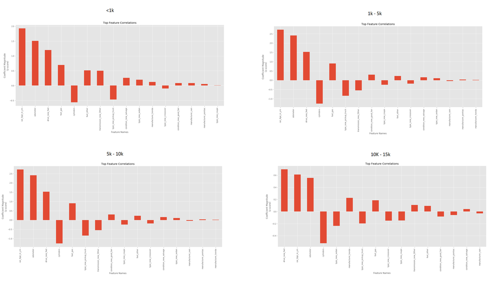

```python
from IPython.display import Image
Image(filename='lessthan15.png')
```

**Interpretation for the following price ranges:**

- From 15k to 30K
- From 30K to 50K
- Greater than 50K

For car prices greater than 15K we can see that age and odometer have negative correlation with the price category. What this means is that these cars are new and have fewer miles on them, thereby commanding higher prices in the used car market. Another interesting observation is that the there is a positive correlation between cylinders and the price ranges. This reaffirms our understanding that we made before that higher cylinders are present in premium / sports cars or trucks that are bought at higher prices, thereby warranting higher prices in the used car market. We can also observer that for each of the three categories the variable type_new_pickup_truck is a positive number indicating presence of pickup trucks, thereby driving the price up as trucks are expensive. Also, we see that some cars in this segment are not run-on gas (fuel_gas is negative indicating absence of this indicator / encoded variable). This means that some of these cars in this price segment run on alternate fuel types. One explanation could be that higher cylinder cars tend to run on diesel / ethanol to increase the mileage. Finally, we want to comment that cars in this segment have a negative value for salvage indicator. This is an important factor as we know that salvage or cars with accidents have lower prices on the used car market.

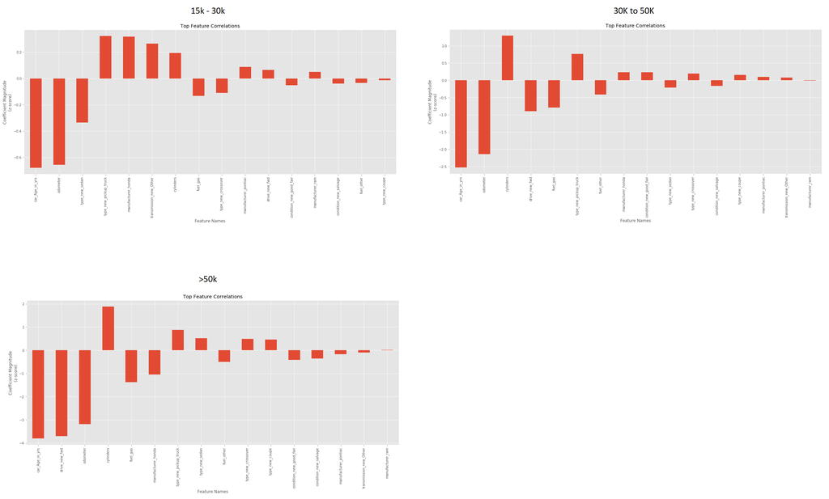

```python
from IPython.display import Image
Image(filename='greaterthan15.png')
```

## Support Vectors

*Look at the chosen support vectors for the classification task. Do these provide any insight into the data? Explain. If you used stochastic gradient descent (and therefore did not explicitly solve for support vectors), try subsampling your data to train the SVC model— then analyze the support vectors from the subsampled dataset.*

This plot shows the kernel density estimation (kde) for five of the important variables in the dataset: cylinders, car_Age_in_yrs, odometer, type_new_pickup_truck, and manufacturer_ford. The plots on the left show the kde for the ~17,000 instances chosen as support vectors while the plots on the right show the kde for the original dataset. The support vector lines are closer together because the data points form the decision boundaries between classes. The original data on the right has more variation because it represents the entire dataset.

**cylinders**

The three peaks show a higher density for 4, 6, and 8 cylinder cars. The other cyclinders have a much lower density.

Cars in the 15-30K price range appear at the top of the plot for 4, 6, and 8 cyclinders and have the highest density between 0.4 - 0.5. They don't have the highest density in the original dataset so more vectors must be needed to create a good boundary.

The two lines near 0.2 are the kde's for cars less than 1K and greater than 50K. These two price ranges have the lowest number of support vectors. They also have low densities in the original dataset, except >50k cars is high for 8-cylinder cars and drops significantly for cars less than 1k.

The vectors for the three remaining ranges are fairly close to the 15-30K vectors, especially for 6-cylinder cars.

**car_Age_in_yrs**

All of the price ranges have a similiar shape.

Again, the pink and blue lines for cars less than 1K and >50K have the lowest density.

The peak for the pink line (>50K) is much higher in the original data than the support vectors. This must mean that fewer support vectors are required to create the decision boundary.

The blue line for cars less than 1k does the opposite. The support vector density is high at ~0.075 near the 7 year mark. Whereas in the original dataset, it stays around 0.05 between 1-20 years.

**odometer**

The density for all price ranges is above 6.0. Interestingly, the density for cars less than 1K peaks around 50,000 miles whereas the other price ranges peak above 100,000 miles. Looking at the original dataset, there seems to be a lot of overlap for that mileage with the other price ranges which could account for the higher density for that category.

**type_new_pickup_truck**

This is a one hot encoded categorical variable. The bi-modal distributions of 0 and 1 are apparent. The 1s represent cars that are classified as a pickup truck. 0s are not pickup trucks and we can see that there are more of those represented here. For the 1s, the density is concentrated for support vectors ranging between 0.5 - 1.5.

**manufacturer_ford**

This is also a one hot encoded categorical variable where 1s are Fords. The plots are very similar between the original and support vectors. The main difference between them is that the density is condensed for the support vectors for the price ranges less than 1k and >50k.

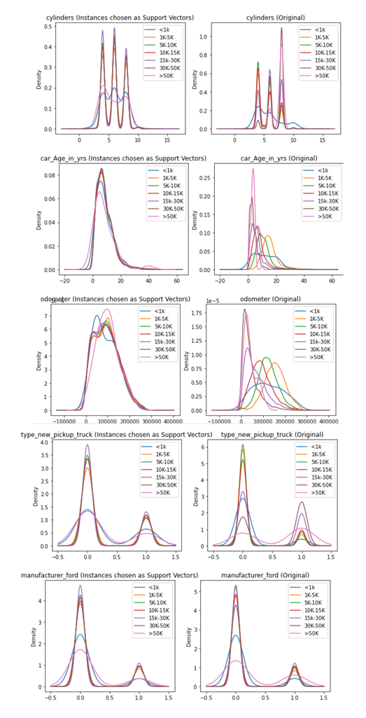

```python
from IPython.display import Image
Image(filename='support_vectors.png')
```

## References

Code from the following notebooks was used for this analysis. References are also noted below when the code is used.

Dr. Drew: https://nbviewer.jupyter.org/github/jakemdrew/EducationDataNC/blob/master/2017/Models/2017ComparingSegregatedHighSchoolCampuses.ipynb  
Dr. Drew: https://nbviewer.jupyter.org/github/jakemdrew/DataMiningNotebooks/blob/master/04.%20Logits%20and%20SVM.ipynb  
Dr. Larson: https://github.com/eclarson/DataMiningNotebooks

## Setup Data

```python
#import libraries
import pandas as pd
import numpy as np
import matplotlib.pyplot as plt
#import plotly.express as px
import seaborn as sns
import json
import time
import statsmodels.api as sm
import statsmodels.stats.multicomp as mc
from datetime import datetime
#from mpl_toolkits.mplot3d import Axes3D
from sklearn.base import BaseEstimator, TransformerMixin
from statsmodels.formula.api import ols
from sklearn.preprocessing import StandardScaler
from sklearn.model_selection import train_test_split
from sklearn.svm import SVC
from sklearn.linear_model import SGDClassifier
from sklearn.feature_selection import SelectPercentile, chi2
from sklearn.model_selection import cross_validate
from sklearn import metrics as mt
from sklearn.metrics import accuracy_score, precision_score, recall_score, make_scorer
from sklearn.metrics import classification_report
from sklearn.model_selection import StratifiedShuffleSplit
from sklearn.linear_model import LogisticRegression
from sklearn.svm import LinearSVC
from sklearn.preprocessing import OneHotEncoder
from sklearn.model_selection import GridSearchCV
from pandas.plotting import boxplot
from sklearn.decomposition import PCA
```

```python
#read data set
#car_df = pd.read_csv('C:/Users/simer/Documents/SMU/DS_7331/DataSets/car_df/out.csv')

#import vehicle dataset
clean_df = pd.read_csv('data/out.csv')
```

```python
car_df = clean_df.copy()
```

```python
#Drop the columns that we will not be using to build models.
car_df = car_df.drop(columns=['model', 'price', 'posting_date'])
```

```python
#One hot encoding of all the features
car_df_encoded = pd.get_dummies(car_df[[ 'manufacturer',
                                         'cylinders',
                                         'fuel',
                                         'odometer',
                                         'title_status',
                                         'drive_new',
                                         'condition_new',
                                         'transmission_new',
                                         'type_new',
                                         'paint_color_new',
                                         'car_Age_in_yrs','state']],  drop_first=True)
car_df_encoded.info()
```

```
<class 'pandas.core.frame.DataFrame'>
RangeIndex: 137526 entries, 0 to 137525
Columns: 121 entries, cylinders to state_wy
dtypes: float64(2), int64(1), uint8(118)
memory usage: 18.6 MB
```

```python
print(car_df_encoded.columns)
```

```
Index(['cylinders', 'odometer', 'car_Age_in_yrs', 'manufacturer_alfa-romeo',
       'manufacturer_aston-martin', 'manufacturer_audi', 'manufacturer_bmw',
       'manufacturer_buick', 'manufacturer_cadillac', 'manufacturer_chevrolet',
       ...
       'state_sd', 'state_tn', 'state_tx', 'state_ut', 'state_va', 'state_vt',
       'state_wa', 'state_wi', 'state_wv', 'state_wy'],
      dtype='object', length=121)
```

```python
#Ccreate numeric column for target- price_range.
price_range_t = [
    (car_df['price_range'] == '<1K') ,
    (car_df['price_range'] == '1K-5K') ,
    (car_df['price_range'] ==  '5K-10K'),
    (car_df['price_range'] == '10K-15K'),
     (car_df['price_range'] == '15k-30K'),
    (car_df['price_range'] == '30K-50K'),
     (car_df['price_range'] == '>50K')
    ]
#new condition categories
price_range_v = [1, 2,3,4,5,6,7]
#new condition column
car_df['price_range_int'] = np.select(price_range_t, price_range_v)
car_df.head()
car_df['price_range_int'].unique()
```

```
array([5, 6, 2, 3, 4, 1, 7])
```

```python
car_df_encoded['price_range_int'] = car_df['price_range_int']
car_df_encoded['price_range_int'].unique()
```

```
array([5, 6, 2, 3, 4, 1, 7])
```

```python
car_df_encoded.info()
```

```
<class 'pandas.core.frame.DataFrame'>
RangeIndex: 137526 entries, 0 to 137525
Columns: 122 entries, cylinders to price_range_int
dtypes: float64(2), int32(1), int64(1), uint8(118)
memory usage: 19.1 MB
```

```python
car_df_encoded_cpy = car_df_encoded.copy()
car_df_encoded_cpy.info()
```

```
<class 'pandas.core.frame.DataFrame'>
RangeIndex: 137526 entries, 0 to 137525
Columns: 122 entries, cylinders to price_range_int
dtypes: float64(2), int32(1), int64(1), uint8(118)
memory usage: 19.1 MB
```

```python
#car_df_enc_small = car_df_encoded_cpy.sample(n=30000)
#y = car_df_enc_small['price_range'].values # get the labels we want
#del car_df_enc_small['price_range'] # get rid of the class label
#X = car_df_enc_small.values

y = car_df_encoded_cpy['price_range_int'].values # get the labels we want
del car_df_encoded_cpy['price_range_int'] # get rid of the class label
X = car_df_encoded_cpy.values # use everything else to predict!
```

```python
len(y)
```

```
137526
```

## Logistic Regression

### GRID SEARCH

```python
#StratifiedShuffleSplit
from sklearn.model_selection import ShuffleSplit
from sklearn.model_selection import StratifiedShuffleSplit
num_cv_iterations = 10
num_instances = len(y)
cv_object = StratifiedShuffleSplit(n_splits=num_cv_iterations,
                         test_size  = 0.2,random_state=42)

print(cv_object)

# now divide the data into test and train using scikit learn built-ins
#from sklearn.model_selection import StratifiedShuffleSplit

#cv = StratifiedShuffleSplit( n_splits=1,test_size=0.5)
```

```
StratifiedShuffleSplit(n_splits=10, random_state=42, test_size=0.2,
            train_size=None)
```

```python
#Scale X

from sklearn.preprocessing import StandardScaler

scl_obj = StandardScaler()
scl_obj.fit(X) # find scalings for each column that make this zero mean and unit std
# the line of code above only looks at training data to get mean and std and we can use it
# to transform new feature data

X_scaled = scl_obj.transform(X) # apply to training
#X_test_scaled = scl_obj.transform(X_test) # apply those means and std to the test set (without snooping at the test set values)
```

```python
from sklearn.model_selection import cross_validate

def EvaluateClassifierEstimator2(classifierEstimator, X, Y, cv):

    #Perform cross validation
    from sklearn.model_selection import cross_val_predict
    predictions = cross_val_predict(classifierEstimator, X, Y, cv=cv)

    #model evaluation
    from sklearn.metrics import classification_report, confusion_matrix, accuracy_score

    #pass true test set values and predictions to classification_report
    classReport = classification_report(Y,predictions)
    confMat = confusion_matrix(Y,predictions)
    acc = accuracy_score(Y,predictions)

    print (classReport)
    print (confMat)
    print (acc)
```

```python
# from sklearn.model_selection import train_test_split
X_train, X_test, y_train, y_test = train_test_split(X_scaled, y, test_size=0.5, random_state=1, stratify=y)
```

```python
# X_train.shape
```

```python
# from sklearn.linear_model import LogisticRegression
# regEstimator = LogisticRegression()
# parameters = { 'penalty':['l2']
#               ,'C': [0.01, 0.1, 1, 10, 100,1000]
#               ,'class_weight': ['balanced']
#               ,'random_state': [42]
#               ,'solver': ['lbfgs','newton-cg']
#               ,'max_iter':[100,500,1000]
#               ,'multi_class': ['multinomial']
#              }
# from sklearn.model_selection import GridSearchCV
# regGridSearch = GridSearchCV(estimator=regEstimator
#                    , n_jobs=8 # jobs to run in parallel
#                    , verbose=1 # low verbosity
#                    , param_grid=parameters
#                    , cv=10 # KFolds = 10
#                    , scoring='accuracy')
# regGridSearch.fit(X_scaled, y)
```

```python
%%time
#Diplay the top model parameters
#regGridSearch.best_estimator_
```

```
Wall time: 0 ns
```

```python
%%time
#Use the best parameters for our Linear Regression object
# classifierEst = regGridSearch.best_estimator_
classifierEst =LogisticRegression(C=1000, class_weight=None, dual=False, fit_intercept=True,
          intercept_scaling=1, max_iter=1000, multi_class='multinomial',
          n_jobs=None, penalty='l2', random_state=42, solver='lbfgs',
          tol=0.0001, verbose=0, warm_start=False)
EvaluateClassifierEstimator2(classifierEst, X_scaled, y, 10)
```

```
              precision    recall  f1-score   support

           1       0.00      0.03      0.01      2370
           2       0.58      0.49      0.53     25572
           3       0.41      0.43      0.42     34574
           4       0.32      0.22      0.26     23465
           5       0.64      0.54      0.59     37334
           6       0.55      0.54      0.54     14025
           7       0.00      0.11      0.01       186

    accuracy                           0.44    137526
   macro avg       0.36      0.34      0.34    137526
weighted avg       0.50      0.44      0.46    137526

[[   68  1049   533   141   220   347    12]
 [ 4457 12644  6748  1353   323     9    38]
 [ 5753  6404 14826  5962  1269    49   311]
 [ 2594  1137  9141  5065  4713   251   564]
 [ 1346   469  4931  3345 20159  5373  1711]
 [   70    30   201   135  4582  7534  1473]
 [    1     0     0     1    34   130    20]]
0.4385788869013859
Wall time: 24min 27s
```

## SGD for Logistic regression

```python
from sklearn.linear_model import SGDClassifier
# linear SVM classifier with stochastic descent
regularize_const = 0.1
iterations = 5
LR_SGD = SGDClassifier(alpha=regularize_const,
        fit_intercept=True, l1_ratio=0.0, learning_rate='optimal',
        loss='log', n_iter_no_change=iterations, n_jobs=-1, penalty='l2')
```

```python
%%time
#svm_sgd.fit(X_scaled,y)

#EvaluateClassifierEstimator2(grid.best_estimator_, X_BestFeatures, y, 10)
EvaluateClassifierEstimator2(LR_SGD, X_scaled, y, 10)
```

```
              precision    recall  f1-score   support

           1       0.50      0.00      0.00      2370
           2       0.61      0.60      0.60     25572
           3       0.44      0.61      0.51     34574
           4       0.32      0.04      0.07     23465
           5       0.50      0.82      0.62     37334
           6       0.39      0.03      0.05     14025
           7       0.00      0.00      0.00       186

    accuracy                           0.50    137526
   macro avg       0.39      0.30      0.27    137526
weighted avg       0.46      0.50      0.43    137526

[[    1  1074   638    13   631    13     0]
 [    0 15248  8989   264  1071     0     0]
 [    1  6688 21172  1256  5443    14     0]
 [    0  1407 11701   879  9448    30     0]
 [    0   639  5181   332 30626   556     0]
 [    0    41    78     1 13511   394     0]
 [    0     0     0     0   181     5     0]]
0.4967787909195352
Wall time: 24.6 s
```

## Feature Selection

### Random Forest

```python
car_dfMulti = car_df_encoded.copy()
car_dfMulti.info()
```

```
<class 'pandas.core.frame.DataFrame'>
RangeIndex: 137526 entries, 0 to 137525
Columns: 122 entries, cylinders to price_range_int
dtypes: float64(2), int32(1), int64(1), uint8(118)
memory usage: 19.1 MB
```

```python
# important for display the plt.show()
%matplotlib inline

import matplotlib.pyplot as plt
from sklearn.ensemble import RandomForestClassifier

feat_labels = car_dfMulti.columns[1:]

forest = RandomForestClassifier(n_estimators=20,random_state=42)

forest.fit(X_scaled, y)
importances = forest.feature_importances_

indices = np.argsort(importances)[::-1]

for f in range(X_train.shape[1]):
    print("%2d) %-*s %f" % (f + 1, 135,
                            feat_labels[indices[f]],
                            importances[indices[f]]))
```

```
 1) car_Age_in_yrs                                                                                                                          0.248445
 2) manufacturer_alfa-romeo                                                                                                                 0.199642
 3) odometer                                                                                                                                0.054197
 4) drive_new_others                                                                                                                        0.030122
 5) type_new_sedan                                                                                                                          0.021154
 6) condition_new_new                                                                                                                       0.020562
 7) paint_color_new_Custom                                                                                                                  0.019229
 8) type_new_coupe                                                                                                                          0.015752
 9) condition_new_good_fair                                                                                                                 0.012317
10) manufacturer_gmc                                                                                                                        0.012301
11) fuel_hybrid                                                                                                                             0.012257
12) type_new_van                                                                                                                            0.011697
13) state_co                                                                                                                                0.011285
14) manufacturer_chrysler                                                                                                                   0.011222
15) manufacturer_volkswagen                                                                                                                 0.010855
16) state_ga                                                                                                                                0.009281
17) type_new_hatchback                                                                                                                      0.008821
18) transmission_new_Other                                                                                                                  0.008002
19) state_oh                                                                                                                                0.007934
20) state_ut                                                                                                                                0.007706
21) manufacturer_pontiac                                                                                                                    0.006722
22) state_ok                                                                                                                                0.006437
23) manufacturer_hyundai                                                                                                                    0.006426
24) title_status_salvage                                                                                                                    0.006261
25) state_mn                                                                                                                                0.006186
26) manufacturer_ferrari                                                                                                                    0.005885
27) state_wv                                                                                                                                0.005736
28) state_nd                                                                                                                                0.005696
29) state_al                                                                                                                                0.005689
30) state_ri                                                                                                                                0.005535
31) state_pa                                                                                                                                0.005327
32) type_new_crossover                                                                                                                      0.005192
33) type_new_mini-van                                                                                                                       0.004990
34) manufacturer_lincoln                                                                                                                    0.004747
35) state_ct                                                                                                                                0.004675
36) state_vt                                                                                                                                0.004549
37) state_md                                                                                                                                0.004544
38) state_id                                                                                                                                0.004497
39) state_nm                                                                                                                                0.004373
40) state_in                                                                                                                                0.004348
```

[output cut: 66 more lines]

```
107) manufacturer_ford                                                                                                                       0.000651
108) type_new_pickup_truck                                                                                                                   0.000616
109) state_fl                                                                                                                                0.000597
110) title_status_parts only                                                                                                                 0.000318
111) state_wy                                                                                                                                0.000303
112) title_status_rebuilt                                                                                                                    0.000173
113) fuel_gas                                                                                                                                0.000169
114) manufacturer_aston-martin                                                                                                               0.000082
115) manufacturer_lexus                                                                                                                      0.000054
116) manufacturer_audi                                                                                                                       0.000047
117) manufacturer_honda                                                                                                                      0.000030
118) manufacturer_dodge                                                                                                                      0.000016
119) manufacturer_toyota                                                                                                                     0.000004
120) drive_new_rwd                                                                                                                           0.000003
121) manufacturer_fiat                                                                                                                       0.000003
```

### ExtraTrees

Xtra Trees: We are using a number of randomized decision trees a.k.a extra-trees Feature Selection as the next feature selection and it is on all the feature variables. All the categorical variables were converted to binary using pandas one hot encoded. We are using random state =42 on this classifier to keep consistent with the other algorithms. The number of estimators is set to 10. By sorting the output from the highest impurity-based feature importances to lowest one, the higher value mean more important the feature, the top 3 features importances are odometer,car age in years and cylinders.

```python
from sklearn.ensemble import ExtraTreesClassifier

# feature extraction
model = ExtraTreesClassifier(n_estimators=10,random_state=42)
model.fit(X_scaled, y)
print(model.feature_importances_.tolist())
```

[output not shown]

### K best

We are using SelectKBest Feature Selection as the next feature selection and it is on all the feature variables. All the categorical variables were converted to binary using pandas one hot encoded. f_classif is chosen for the score function due to the needs of performing classification tasks on our dataset. The number of top features to select, k is set to 10. The higher the score value is the higher of feature importances. The top 3 features importances from this are odometer, car age in years and cylinders.

```python
from numpy import set_printoptions
from sklearn.feature_selection import SelectKBest
from sklearn.feature_selection import f_classif


# feature extraction
test = SelectKBest(score_func=f_classif, k=10)
fit = test.fit(X_scaled, y)
# summarize scores
set_printoptions(precision=3)
print(fit.scores_.tolist())
features = fit.transform(X_scaled)
```

[output not shown]

### Recursive Feature Elimination Cross Validation

We are using Recursive Feature Elimination Cross Validation (RFECV) as our next feature selection technique and it is run on all the feature variables. All the categorical variables were converted to binary using pandas one hot encoding. The parameter passed to this are: estimator = lr_clf. This holds the best model from logistic regression grid search. Step =1. One feature to remove on each run. CV = 10 scoring = 'accuracy' The outputs assesed are: grid*scores* = The cross-validation scores such that grid*scores*[i] corresponds to the CV score of the i-th subset of features. ranking *= The feature ranking, such that ranking*[i] corresponds to the ranking position of the i-th feature. Selected (i.e., estimated best) features are assigned rank 1.

```python
#X_train is the smaller dataset with ~34K rows and all 121 columns.We are running RFECV on this.
#X_scaled1 = X_scaled['cylinders', 'odometer', 'car_Age_in_yrs']


col_names = car_df_encoded.columns
top_features_df = car_df_encoded[col_names]
top_features_df.info(verbose=False)
print(col_names)
y = top_features_df['price_range_int'].values # get the labels we want
del top_features_df['price_range_int'] # get rid of the class label
X = top_features_df.values # use everything else to predict!

scl_obj = StandardScaler()
scl_obj.fit(X) # find scalings for each column that make this zero mean and unit std
# the line of code above only looks at training data to get mean and std and we can use it
# to transform new feature data

X_scaled = scl_obj.transform(X)
```

```
<class 'pandas.core.frame.DataFrame'>
RangeIndex: 137526 entries, 0 to 137525
Columns: 122 entries, cylinders to price_range_int
dtypes: float64(2), int32(1), int64(1), uint8(118)
memory usage: 19.1 MB
Index(['cylinders', 'odometer', 'car_Age_in_yrs', 'manufacturer_alfa-romeo',
       'manufacturer_aston-martin', 'manufacturer_audi', 'manufacturer_bmw',
       'manufacturer_buick', 'manufacturer_cadillac', 'manufacturer_chevrolet',
       ...
       'state_tn', 'state_tx', 'state_ut', 'state_va', 'state_vt', 'state_wa',
       'state_wi', 'state_wv', 'state_wy', 'price_range_int'],
      dtype='object', length=122)
```

```python
# %%time
# from sklearn.feature_selection import RFECV
# ref = RFECV(lr_clf, step=1, cv =10, scoring='accuracy')
# ref.fit(X_scaled, y)
# print(ref.grid_scores_)
```

```python
# Examine categorical variables of interest
import matplotlib.pyplot as plt
%matplotlib inline

#print("Optimal number of features : %d" % ref.n_features_)

# Plot number of features VS. cross-validation scores
# plt.figure()
# plt.xlabel("Number of features selected")
# plt.ylabel("Cross validation score (nb of correct classifications)")
# plt.plot(range(1, len(ref.grid_scores_) + 1), ref.grid_scores_)
# plt.show()
```

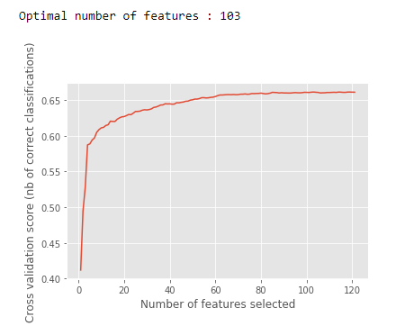

```python
from IPython.display import Image
Image(filename='optimal_features.png')
```

#### This code was used but is commented out from the final document to save on runtime. RFE takes around six hours to complete on the entire dataset. Instead the results were saved to a csv and used to run the performance of the top n features.

```python
#Print RFE Rankings & GridSearch scores
# rfe_ft_imp_df = pd.DataFrame({'feature_names':car_df_encoded_cpy.columns, 'weights':ref.grid_scores_, 'Rnk':ref.ranking_})
# rfe_ft_imp_df.sort_values(by='weights', inplace=True, ascending=False )
# rfe_ft_imp_df = rfe_ft_imp_df[rfe_rnk_imp_df.Rnk==1]
# rfe_ft_imp_df = rfe_ft_imp_df.sort_values(by = 'weights', ascending=False)
# rfe_ft_imp_df
```

```python
pd.options.display.max_rows = 200
#results of RFE from code above
rfe_ft_imp_df_All_Ranks = pd.read_csv('data/rfe_ft_imp_df_All_Ranks.csv', header= 0)
rfe_ft_imp_df_All_Ranks
```

|  | ID | feature_names | weights | Rnk |
| --- | --- | --- | --- | --- |
| 0 | 102 | state_nm | 0.661123 | 10 |
| 1 | 113 | state_tx | 0.661094 | 1 |
| 2 | 117 | state_wa | 0.661094 | 15 |
| 3 | 118 | state_wi | 0.661093 | 4 |
| 4 | 119 | state_wv | 0.660977 | 1 |
| 5 | 114 | state_ut | 0.660948 | 1 |
| 6 | 101 | state_nj | 0.660919 | 1 |
| 7 | 120 | state_wy | 0.660890 | 1 |
| 8 | 103 | state_nv | 0.660832 | 1 |
| 9 | 111 | state_sd | 0.660803 | 1 |
| 10 | 98 | state_nd | 0.660774 | 1 |
| 11 | 84 | state_il | 0.660744 | 1 |
| 12 | 116 | state_vt | 0.660687 | 1 |
| 13 | 115 | state_va | 0.660686 | 1 |
| 14 | 99 | state_ne | 0.660657 | 1 |
| 15 | 110 | state_sc | 0.660657 | 1 |
| 16 | 112 | state_tn | 0.660628 | 18 |
| 17 | 104 | state_ny | 0.660599 | 1 |
| 18 | 100 | state_nh | 0.660512 | 1 |
| 19 | 108 | state_pa | 0.660512 | 1 |
| 20 | 109 | state_ri | 0.660512 | 1 |
| 21 | 85 | state_in | 0.660511 | 1 |
| 22 | 86 | state_ks | 0.660366 | 5 |
| 23 | 94 | state_mo | 0.660337 | 7 |
| 24 | 97 | state_nc | 0.660250 | 1 |
| 25 | 88 | state_la | 0.660162 | 12 |
| 26 | 107 | state_or | 0.660134 | 1 |
| 27 | 93 | state_mn | 0.660104 | 1 |
| 28 | 95 | state_ms | 0.660104 | 1 |
| 29 | 106 | state_ok | 0.660046 | 9 |

[output cut: 91 more lines]

```python
pd.options.display.max_rows = 200
#rank 1 results to be used in top n features
rfe_ft_imp_df = rfe_ft_imp_df_All_Ranks[rfe_ft_imp_df_All_Ranks['Rnk']==1]
rfe_ft_imp_df
```

|  | ID | feature_names | weights | Rnk |
| --- | --- | --- | --- | --- |
| 1 | 113 | state_tx | 0.661094 | 1 |
| 4 | 119 | state_wv | 0.660977 | 1 |
| 5 | 114 | state_ut | 0.660948 | 1 |
| 6 | 101 | state_nj | 0.660919 | 1 |
| 7 | 120 | state_wy | 0.660890 | 1 |
| 8 | 103 | state_nv | 0.660832 | 1 |
| 9 | 111 | state_sd | 0.660803 | 1 |
| 10 | 98 | state_nd | 0.660774 | 1 |
| 11 | 84 | state_il | 0.660744 | 1 |
| 12 | 116 | state_vt | 0.660687 | 1 |
| 13 | 115 | state_va | 0.660686 | 1 |
| 14 | 99 | state_ne | 0.660657 | 1 |
| 15 | 110 | state_sc | 0.660657 | 1 |
| 17 | 104 | state_ny | 0.660599 | 1 |
| 18 | 100 | state_nh | 0.660512 | 1 |
| 19 | 108 | state_pa | 0.660512 | 1 |
| 20 | 109 | state_ri | 0.660512 | 1 |
| 21 | 85 | state_in | 0.660511 | 1 |
| 24 | 97 | state_nc | 0.660250 | 1 |
| 26 | 107 | state_or | 0.660134 | 1 |
| 27 | 93 | state_mn | 0.660104 | 1 |
| 28 | 95 | state_ms | 0.660104 | 1 |
| 30 | 96 | state_mt | 0.660017 | 1 |
| 31 | 105 | state_oh | 0.659872 | 1 |
| 33 | 89 | state_ma | 0.659842 | 1 |
| 35 | 92 | state_mi | 0.659726 | 1 |
| 36 | 91 | state_me | 0.659726 | 1 |
| 37 | 79 | state_fl | 0.659639 | 1 |
| 38 | 83 | state_id | 0.659581 | 1 |
| 39 | 78 | state_de | 0.659203 | 1 |

[output cut: 73 more lines]

## LR model from gridsearch on all 103 columns

```python
%%time
from sklearn.linear_model import LogisticRegression


lr_clf =LogisticRegression(C=1000, class_weight=None, dual=False, fit_intercept=True,
          intercept_scaling=1, max_iter=1000, multi_class='multinomial',
          n_jobs=None, penalty='l2', random_state=42, solver='lbfgs',
          tol=0.0001, verbose=0, warm_start=False)
```

```
Wall time: 995 µs
```

```python
%%time
#top_features_df = column_names(car_df_encoded)
#top_features_df.info(verbose=False)
# col_names = car_df_encoded.columns
# top_features_df = car_df_encoded[col_names]
# top_features_df.info(verbose=False)
# print(col_names)


n= 103
topfeatures = rfe_ft_imp_df.head(n)

#Create dataframe with only the top columns + our response variable
col_names = topfeatures['feature_names'].ravel()
addnl_columns = ['price_range_int']
#col_names = np.append(col_names, 'price_range','cylinders','odometer','car_Age_in_yrs')
col_names = np.append(col_names,addnl_columns)
top_features_df = car_df_encoded[col_names]
top_features_df.info(verbose=False)

y = top_features_df['price_range_int'].values # get the labels we want
del top_features_df['price_range_int'] # get rid of the class label
X = top_features_df.values # use everything else to predict!

len(y)
scl_obj = StandardScaler()
scl_obj.fit(X) # find scalings for each column that make this zero mean and unit std
# the line of code above only looks at training data to get mean and std and we can use it
# to transform new feature data

X_scaled = scl_obj.transform(X)
```

```
<class 'pandas.core.frame.DataFrame'>
RangeIndex: 137526 entries, 0 to 137525
Columns: 104 entries, state_tx to price_range_int
dtypes: float64(2), int32(1), int64(1), uint8(100)
memory usage: 16.8 MB
Wall time: 1.31 s
```

```python
%%time
#EvaluateClassifierEstimator2(grid.best_estimator_, X_BestFeatures, y, 10)
EvaluateClassifierEstimator2(lr_clf, X_scaled, y, 10)
```

```
              precision    recall  f1-score   support

           1       0.01      0.03      0.01      2370
           2       0.64      0.51      0.57     25572
           3       0.45      0.53      0.49     34574
           4       0.39      0.26      0.31     23465
           5       0.67      0.60      0.63     37334
           6       0.61      0.60      0.60     14025
           7       0.01      0.04      0.01       186

    accuracy                           0.50    137526
   macro avg       0.40      0.37      0.37    137526
weighted avg       0.54      0.50      0.51    137526

[[   70  1048   536   144   214   347    11]
 [ 4021 13163  7338   715   323     9     3]
 [ 4985  5187 18213  4917  1223    18    31]
 [ 2272   749  9275  5987  5027   101    54]
 [ 1286   263  4730  3466 22285  4802   502]
 [   68    28   218   118  4406  8369   818]
 [    1     0     0     1    25   151     8]]
0.49514273664616143
Wall time: 20min 22s
```

## LR model from gridsearch on Top 60 columns from RFE

```python
%%time
n= 60
topfeatures = rfe_ft_imp_df.tail(n)

#Create dataframe with only the top columns + our response variable
col_names = topfeatures['feature_names'].ravel()
addnl_columns = ['price_range_int']
col_names = np.append(col_names,addnl_columns)
top_features_df = car_df_encoded[col_names]
top_features_df.info(verbose=False)

y = top_features_df['price_range_int'].values # get the labels we want
del top_features_df['price_range_int'] # get rid of the class label
X = top_features_df.values # use everything else to predict!

len(y)
scl_obj = StandardScaler()
scl_obj.fit(X) # find scalings for each column that make this zero mean and unit std
# the line of code above only looks at training data to get mean and std and we can use it
# to transform new feature data

X_scaled = scl_obj.transform(X)
```

```
<class 'pandas.core.frame.DataFrame'>
RangeIndex: 137526 entries, 0 to 137525
Columns: 61 entries, paint_color_new_BluRdBrwn to price_range_int
dtypes: float64(2), int32(1), int64(1), uint8(57)
memory usage: 11.1 MB
Wall time: 524 ms
```

```python
%%time
#EvaluateClassifierEstimator2(grid.best_estimator_, X_BestFeatures, y, 10)
EvaluateClassifierEstimator2(lr_clf, X_scaled, y, 10)
```

```
              precision    recall  f1-score   support

           1       0.14      0.01      0.03      2370
           2       0.73      0.68      0.70     25572
           3       0.59      0.73      0.65     34574
           4       0.53      0.31      0.39     23465
           5       0.66      0.78      0.72     37334
           6       0.72      0.65      0.68     14025
           7       0.00      0.00      0.00       186

    accuracy                           0.64    137526
   macro avg       0.48      0.45      0.45    137526
weighted avg       0.63      0.64      0.63    137526

[[   33  1057   463   150   311   356     0]
 [   75 17265  7638   225   366     3     0]
 [   77  4807 25235  2906  1534    15     0]
 [   39   425  7936  7326  7708    31     0]
 [   12   224  1658  3160 29269  3011     0]
 [    0    33    41    56  4812  9083     0]
 [    0     0     0     0    28   158     0]]
0.6414132600381018
Wall time: 13min 21s
```

## LR model from gridsearch on Top 30 columns from RFE

```python
n= 30
topfeatures = rfe_ft_imp_df.tail(n)

#Create dataframe with only the top columns + our response variable
col_names = topfeatures['feature_names'].ravel()
addnl_columns = ['price_range_int']
#col_names = np.append(col_names, 'price_range','cylinders','odometer','car_Age_in_yrs')
col_names = np.append(col_names,addnl_columns)
top_features_df = car_df_encoded[col_names]
top_features_df.info(verbose=False)

y = top_features_df['price_range_int'].values # get the labels we want
del top_features_df['price_range_int'] # get rid of the class label
X = top_features_df.values # use everything else to predict!

len(y)
scl_obj = StandardScaler()
scl_obj.fit(X) # find scalings for each column that make this zero mean and unit std
# the line of code above only looks at training data to get mean and std and we can use it
# to transform new feature data

X_scaled = scl_obj.transform(X)
```

```
<class 'pandas.core.frame.DataFrame'>
RangeIndex: 137526 entries, 0 to 137525
Columns: 31 entries, manufacturer_nissan to price_range_int
dtypes: float64(2), int32(1), int64(1), uint8(27)
memory usage: 7.2 MB
```

```python
%%time
EvaluateClassifierEstimator2(lr_clf, X_scaled, y, 10)
```

```
              precision    recall  f1-score   support

           1       0.00      0.00      0.00      2370
           2       0.68      0.61      0.64     25572
           3       0.54      0.71      0.61     34574
           4       0.51      0.19      0.27     23465
           5       0.59      0.79      0.68     37334
           6       0.68      0.51      0.58     14025
           7       0.00      0.00      0.00       186

    accuracy                           0.59    137526
   macro avg       0.43      0.40      0.40    137526
weighted avg       0.58      0.59      0.56    137526

[[    0  1001   565   100   351   353     0]
 [    0 15585  9300   126   557     4     0]
 [    0  4878 24632  2165  2881    18     0]
 [    0   810  8523  4357  9733    42     0]
 [    0   539  2814  1715 29520  2746     0]
 [    0    44   160    82  6616  7123     0]
 [    0     0     0     1    68   117     0]]
0.5905574218693193
Wall time: 9min 41s
```

## LR model from gridsearch on Top 20 columns from RFE

```python
n= 20
topfeatures = rfe_ft_imp_df.tail(n)

#Create dataframe with only the top columns + our response variable
col_names = topfeatures['feature_names'].ravel()
addnl_columns = ['price_range_int']
#col_names = np.append(col_names, 'price_range','cylinders','odometer','car_Age_in_yrs')
col_names = np.append(col_names,addnl_columns)
top_features_df = car_df_encoded[col_names]
top_features_df.info(verbose=False)

y = top_features_df['price_range_int'].values # get the labels we want
del top_features_df['price_range_int'] # get rid of the class label
X = top_features_df.values # use everything else to predict!

len(y)
scl_obj = StandardScaler()
scl_obj.fit(X) # find scalings for each column that make this zero mean and unit std
# the line of code above only looks at training data to get mean and std and we can use it
# to transform new feature data

X_scaled = scl_obj.transform(X)
```

```
<class 'pandas.core.frame.DataFrame'>
RangeIndex: 137526 entries, 0 to 137525
Columns: 21 entries, manufacturer_jaguar to price_range_int
dtypes: float64(2), int32(1), int64(1), uint8(17)
memory usage: 5.9 MB
```

```python
%%time
EvaluateClassifierEstimator2(lr_clf, X_scaled, y, 10)
```

```
              precision    recall  f1-score   support

           1       0.00      0.00      0.00      2370
           2       0.67      0.59      0.63     25572
           3       0.53      0.71      0.60     34574
           4       0.50      0.16      0.24     23465
           5       0.58      0.80      0.67     37334
           6       0.69      0.49      0.57     14025
           7       0.00      0.00      0.00       186

    accuracy                           0.58    137526
   macro avg       0.42      0.39      0.39    137526
weighted avg       0.57      0.58      0.55    137526

[[    0   999   554    95   373   349     0]
 [    0 15185  9610   131   629    17     0]
 [    0  4985 24418  1961  3198    12     0]
 [    0   873  8756  3723 10089    24     0]
 [    0   615  2863  1511 29742  2603     0]
 [    0    50   172    26  6868  6909     0]
 [    0     0     0     1    70   115     0]]
0.5815409449849483
Wall time: 7min 40s
```

```python
# #Top 20 features from K best
Top20K_best = ['odometer','car_Age_in_yrs','type_new_pickup_truck','transmission_new_Other','cylinders','drive_new_fwd','type_new_sedan','condition_new_good_fair','fuel_gas','fuel_other','manufacturer_ram','type_new_crossover','type_new_coupe','condition_new_salvage','manufacturer_pontiac','manufacturer_honda']
col_names = np.append(Top20K_best, 'price_range_int')
top_features_df = car_df_encoded[col_names]
top_features_df.info(verbose=False)
print(col_names)
```

```
<class 'pandas.core.frame.DataFrame'>
RangeIndex: 137526 entries, 0 to 137525
Columns: 17 entries, odometer to price_range_int
dtypes: float64(2), int32(1), int64(1), uint8(13)
memory usage: 5.4 MB
['odometer' 'car_Age_in_yrs' 'type_new_pickup_truck'
 'transmission_new_Other' 'cylinders' 'drive_new_fwd' 'type_new_sedan'
 'condition_new_good_fair' 'fuel_gas' 'fuel_other' 'manufacturer_ram'
 'type_new_crossover' 'type_new_coupe' 'condition_new_salvage'
 'manufacturer_pontiac' 'manufacturer_honda' 'price_range_int']
```

```python
y = top_features_df['price_range_int'].values # get the labels we want
del top_features_df['price_range_int'] # get rid of the class label
X = top_features_df.values # use everything else to predict!

scl_obj = StandardScaler()
scl_obj.fit(X) # find scalings for each column that make this zero mean and unit std
# the line of code above only looks at training data to get mean and std and we can use it
# to transform new feature data

X_scaled = scl_obj.transform(X)
```

```python
%%time
#EvaluateClassifierEstimator2(grid.best_estimator_, X_BestFeatures, y, 10)
EvaluateClassifierEstimator2(lr_clf, X_scaled, y, 10)
```

```
              precision    recall  f1-score   support

           1       0.11      0.01      0.01      2370
           2       0.71      0.66      0.68     25572
           3       0.57      0.71      0.63     34574
           4       0.51      0.28      0.36     23465
           5       0.64      0.78      0.70     37334
           6       0.69      0.59      0.64     14025
           7       0.00      0.00      0.00       186

    accuracy                           0.62    137526
   macro avg       0.46      0.43      0.43    137526
weighted avg       0.61      0.62      0.60    137526

[[   19  1041   494   134   361   321     0]
 [   73 16808  8064   191   418    18     0]
 [   53  5151 24529  2975  1851    15     0]
 [   33   510  8301  6651  7931    39     0]
 [    2   249  1848  3150 28985  3100     0]
 [    0    40    32    24  5693  8236     0]
 [    0     0     0     0    18   168     0]]
0.6197228160493289
Wall time: 8min 3s
```

```python
#Top 20 features from Xtra trees
TopXtra_best = ['odometer','car_Age_in_yrs','cylinders','type_new_pickup_truck','transmission_new_Other','drive_new_fwd','manufacturer_ford','manufacturer_chevrolet','state_ca','type_new_sedan','paint_color_new_BluRdBrwn','manufacturer_toyota','condition_new_good_fair','state_fl','state_ny','state_tx']
col_names = np.append(TopXtra_best, 'price_range_int')
top_features_df = car_df_encoded[col_names]
top_features_df.info(verbose=False)
```

```
<class 'pandas.core.frame.DataFrame'>
RangeIndex: 137526 entries, 0 to 137525
Columns: 17 entries, odometer to price_range_int
dtypes: float64(2), int32(1), int64(1), uint8(13)
memory usage: 5.4 MB
```

```python
y = top_features_df['price_range_int'].values # get the labels we want
del top_features_df['price_range_int'] # get rid of the class label
X = top_features_df.values # use everything else to predict!

scl_obj = StandardScaler()
scl_obj.fit(X) # find scalings for each column that make this zero mean and unit std
# the line of code above only looks at training data to get mean and std and we can use it
# to transform new feature data

X_scaled = scl_obj.transform(X)
```

```python
%%time
#EvaluateClassifierEstimator2(grid.best_estimator_, X_BestFeatures, y, 10)
EvaluateClassifierEstimator2(lr_clf, X_scaled, y, 10)
```

```
              precision    recall  f1-score   support

           1       0.02      0.01      0.01      2370
           2       0.70      0.62      0.66     25572
           3       0.51      0.69      0.59     34574
           4       0.47      0.24      0.32     23465
           5       0.62      0.69      0.65     37334
           6       0.61      0.58      0.60     14025
           7       0.00      0.00      0.00       186

    accuracy                           0.58    137526
   macro avg       0.42      0.41      0.40    137526
weighted avg       0.57      0.58      0.56    137526

[[   21  1024   570   105   319   328     3]
 [  311 15959  8485   365   440    11     1]
 [  481  4849 23972  3304  1946    22     0]
 [  265   618  9473  5734  7259   116     0]
 [  250   343  3940  2657 25604  4518    22]
 [    7    38   276    70  5390  8185    59]
 [    0     0     2     0    38   146     0]]
0.5778907261172432
Wall time: 5min 19s
```

```python
#Top 20 features from Random Forest
TopRandomForest = ['odometer','car_Age_in_yrs','cylinders','type_new_pickup_truck','drive_new_fwd','transmission_new_Other','drive_new_4wd','manufacturer_ford','manufacturer_chevrolet','paint_color_new_BlSlvrWhGryMsng','manufacturer_toyota','paint_color_new_BluRdBrwn','type_new_sedan','state_ca','condition_new_excellent_likenew','state_fl','condition_new_good_fair','transmission_new_Automatic','drive_new_rwd','type_new_crossover']
col_names = np.append(TopXtra_best, 'price_range_int')
top_features_df = car_df_encoded[col_names]
top_features_df.info(verbose=False)
```

```
<class 'pandas.core.frame.DataFrame'>
RangeIndex: 137526 entries, 0 to 137525
Columns: 17 entries, odometer to price_range_int
dtypes: float64(2), int32(1), int64(1), uint8(13)
memory usage: 5.4 MB
```

```python
y = top_features_df['price_range_int'].values # get the labels we want
del top_features_df['price_range_int'] # get rid of the class label
X = top_features_df.values # use everything else to predict!

scl_obj = StandardScaler()
scl_obj.fit(X) # find scalings for each column that make this zero mean and unit std
# the line of code above only looks at training data to get mean and std and we can use it
# to transform new feature data

X_scaled = scl_obj.transform(X)
```

```python
%%time
#EvaluateClassifierEstimator2(grid.best_estimator_, X_BestFeatures, y, 10)
EvaluateClassifierEstimator2(lr_clf, X_scaled, y, 10)
```

```
              precision    recall  f1-score   support

           1       0.02      0.01      0.01      2370
           2       0.70      0.62      0.66     25572
           3       0.51      0.69      0.59     34574
           4       0.47      0.24      0.32     23465
           5       0.62      0.69      0.65     37334
           6       0.61      0.58      0.60     14025
           7       0.00      0.00      0.00       186

    accuracy                           0.58    137526
   macro avg       0.42      0.41      0.40    137526
weighted avg       0.57      0.58      0.56    137526

[[   21  1024   570   105   319   328     3]
 [  311 15959  8485   365   440    11     1]
 [  481  4849 23972  3304  1946    22     0]
 [  265   618  9473  5734  7259   116     0]
 [  250   343  3940  2657 25604  4518    22]
 [    7    38   276    70  5390  8185    59]
 [    0     0     2     0    38   146     0]]
0.5778907261172432
Wall time: 5min 52s
```

## Coefficients for the model with the highest accuracy

```python
#Model with the following features has the best accuracy
Features = ['odometer','car_Age_in_yrs','type_new_pickup_truck','transmission_new_Other','cylinders','drive_new_fwd','type_new_sedan','condition_new_good_fair','fuel_gas','fuel_other','manufacturer_ram','type_new_crossover','type_new_coupe','condition_new_salvage','manufacturer_pontiac','manufacturer_honda']
col_names = np.append(Features, 'price_range_int')
top_features_df = car_df_encoded[col_names]
top_features_df.info(verbose=False)
y = top_features_df['price_range_int'].values # get the labels we want
del top_features_df['price_range_int'] # get rid of the class label
X = top_features_df.values # use everything else to predict!

scl_obj = StandardScaler()
scl_obj.fit(X) # find scalings for each column that make this zero mean and unit std
# the line of code above only looks at training data to get mean and std and we can use it
# to transform new feature data

X_scaled = scl_obj.transform(X)
```

```
<class 'pandas.core.frame.DataFrame'>
RangeIndex: 137526 entries, 0 to 137525
Columns: 17 entries, odometer to price_range_int
dtypes: float64(2), int32(1), int64(1), uint8(13)
memory usage: 5.4 MB
```

```python
%%time
lr_clf.fit(X_scaled,y)
#EvaluateClassifierEstimator2(grid.best_estimator_, X_BestFeatures, y, 10)
#EvaluateClassifierEstimator2(lr_clf, X_scaled, y, 10)
```

```
Wall time: 47.7 s
```

```
LogisticRegression(C=1000, max_iter=1000, multi_class='multinomial',
                   random_state=42)
```

# coef[0]

```python
# interpret the weights

# iterate over the coefficients
weights = lr_clf.coef_[0] # take transpose to make a column vector
variable_names = ['odometer','car_Age_in_yrs','type_new_pickup_truck','transmission_new_Other','cylinders','drive_new_fwd','type_new_sedan','condition_new_good_fair','fuel_gas','fuel_other','manufacturer_ram','type_new_crossover','type_new_coupe','condition_new_salvage','manufacturer_pontiac','manufacturer_honda']
for coef, name in zip(weights,variable_names):
    print(name, 'has weight of', coef)
```

```
odometer has weight of 1.504203286558076
car_Age_in_yrs has weight of 1.9245562866607218
type_new_pickup_truck has weight of -0.4677933178621428
transmission_new_Other has weight of 0.49844829504458504
cylinders has weight of -0.5593201660505563
drive_new_fwd has weight of 1.177016740034697
type_new_sedan has weight of 0.1967038759292174
condition_new_good_fair has weight of 0.08602016383555666
fuel_gas has weight of 0.6918791061900037
fuel_other has weight of 0.515584832553374
manufacturer_ram has weight of 0.08332078642498328
type_new_crossover has weight of -0.10054137807249819
type_new_coupe has weight of 0.007588773576559841
condition_new_salvage has weight of 0.26252445670784885
manufacturer_pontiac has weight of 0.04443650525467477
manufacturer_honda has weight of 0.10779522673860957
```

```python
weights = lr_clf.coef_[0]
#weights.shape
feature_names = ['odometer','car_Age_in_yrs','type_new_pickup_truck','transmission_new_Other','cylinders','drive_new_fwd','type_new_sedan','condition_new_good_fair','fuel_gas','fuel_other','manufacturer_ram','type_new_crossover','type_new_coupe','condition_new_salvage','manufacturer_pontiac','manufacturer_honda']
#len(feature_names)
linreg_ft_imp_df = pd.DataFrame({'feature_names':feature_names, 'weights':weights, 'absolute_weights': np.abs(weights)})
linreg_ft_imp_df.sort_values(by='absolute_weights', inplace=True, ascending=False )
```

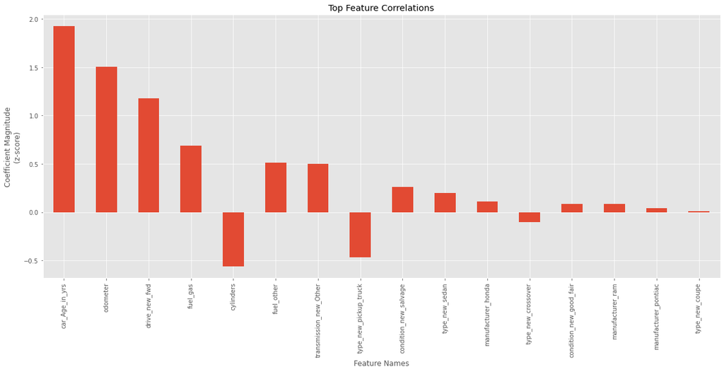

```python
# Examine categorical variables of interest
import matplotlib.pyplot as plt
%matplotlib inline

#Plot the model's feature importances
# REFERENCE:  Eric Larson, https://github.com/eclarson/DataMiningNotebooks
plt.style.use('ggplot')

wt_plt_df = linreg_ft_imp_df.head(75)

weights = pd.Series(wt_plt_df['weights'].values,index=wt_plt_df['feature_names'])
ax = weights.plot(kind='bar', figsize=(20,8))

ax.set_title("Top Feature Correlations")
ax.set_ylabel("Coefficient Magnitude\n(z-score)")
ax.set_xlabel("Feature Names")
plt.show()
```

# coef[1]

```python
# interpret the weights

# iterate over the coefficients
weights = lr_clf.coef_[1] # take transpose to make a column vector
variable_names = ['odometer','car_Age_in_yrs','type_new_pickup_truck','transmission_new_Other','cylinders','drive_new_fwd','type_new_sedan','condition_new_good_fair','fuel_gas','fuel_other','manufacturer_ram','type_new_crossover','type_new_coupe','condition_new_salvage','manufacturer_pontiac','manufacturer_honda']
for coef, name in zip(weights,variable_names):
    print(name, 'has weight of', coef)
```

```
odometer has weight of 2.406943900194093
car_Age_in_yrs has weight of 2.7150998660637486
type_new_pickup_truck has weight of -0.8379838019427777
transmission_new_Other has weight of -0.5449563233674426
cylinders has weight of -1.2543114375168103
drive_new_fwd has weight of 1.5050711777793089
type_new_sedan has weight of 0.10674545860506636
condition_new_good_fair has weight of 0.29372384078840275
fuel_gas has weight of 0.899833224982575
fuel_other has weight of 0.2233921559042687
manufacturer_ram has weight of -0.04473278249600118
type_new_crossover has weight of -0.18323956241157585
type_new_coupe has weight of -0.2486225951155743
condition_new_salvage has weight of 0.15653569180133886
manufacturer_pontiac has weight of 0.022182219141676285
manufacturer_honda has weight of 0.004232360354459085
```

```python
weights = lr_clf.coef_[1]
#weights.shape
feature_names = ['odometer','car_Age_in_yrs','type_new_pickup_truck','transmission_new_Other','cylinders','drive_new_fwd','type_new_sedan','condition_new_good_fair','fuel_gas','fuel_other','manufacturer_ram','type_new_crossover','type_new_coupe','condition_new_salvage','manufacturer_pontiac','manufacturer_honda']
#len(feature_names)
linreg_ft_imp_df = pd.DataFrame({'feature_names':feature_names, 'weights':weights, 'absolute_weights': np.abs(weights)})
linreg_ft_imp_df.sort_values(by='absolute_weights', inplace=True, ascending=False )
```

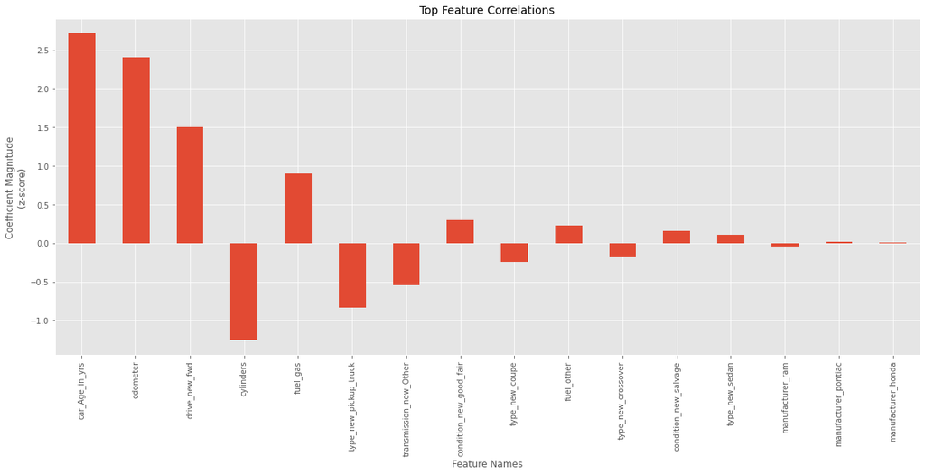

```python
# Examine categorical variables of interest
import matplotlib.pyplot as plt
%matplotlib inline

#Plot the model's feature importances
# REFERENCE:  Eric Larson, https://github.com/eclarson/DataMiningNotebooks
plt.style.use('ggplot')

wt_plt_df = linreg_ft_imp_df.head(75)

weights = pd.Series(wt_plt_df['weights'].values,index=wt_plt_df['feature_names'])
ax = weights.plot(kind='bar', figsize=(20,8))

ax.set_title("Top Feature Correlations")
ax.set_ylabel("Coefficient Magnitude\n(z-score)")
ax.set_xlabel("Feature Names")
plt.show()
```

# coef[2]

```python
# interpret the weights

# iterate over the coefficients
weights = lr_clf.coef_[2] # take transpose to make a column vector
variable_names = ['odometer','car_Age_in_yrs','type_new_pickup_truck','transmission_new_Other','cylinders','drive_new_fwd','type_new_sedan','condition_new_good_fair','fuel_gas','fuel_other','manufacturer_ram','type_new_crossover','type_new_coupe','condition_new_salvage','manufacturer_pontiac','manufacturer_honda']
for coef, name in zip(weights,variable_names):
    print(name, 'has weight of', coef)
```

```
odometer has weight of 1.5120375638097463
car_Age_in_yrs has weight of 1.7410530108606463
type_new_pickup_truck has weight of -0.4678600123951468
transmission_new_Other has weight of -0.3017342893156431
cylinders has weight of -1.0197798558427205
drive_new_fwd has weight of 1.077151104841989
type_new_sedan has weight of -0.03460586244971876
condition_new_good_fair has weight of -0.07422941971867046
fuel_gas has weight of 0.5262384020955876
fuel_other has weight of 0.12233621309690541
manufacturer_ram has weight of -0.062007819165790574
type_new_crossover has weight of -0.14823446056281075
type_new_coupe has weight of -0.21728625876959276
condition_new_salvage has weight of 0.10117098085315619
manufacturer_pontiac has weight of -0.04899869149150365
manufacturer_honda has weight of 0.11810317577890424
```

```python
#Load the model's coefficient weights and feature names into a dataframe sorted by weights
# interpret the weights

# iterate over the coefficients
#weights = lr_clf.coef_[0] # take transpose to make a column vector
#variable_names = ['odometer','car_Age_in_yrs','type_new_pickup_truck','transmission_new_Other','cylinders','drive_new_fwd','type_new_sedan','condition_new_good_fair','fuel_gas','fuel_other','manufacturer_ram','type_new_crossover','type_new_coupe','condition_new_salvage','manufacturer_pontiac','manufacturer_honda']
#for coef, name in zip(weights,variable_names):
#    print(name, 'has weight of', coef)

weights = lr_clf.coef_[2]
#weights.shape
feature_names = ['odometer','car_Age_in_yrs','type_new_pickup_truck','transmission_new_Other','cylinders','drive_new_fwd','type_new_sedan','condition_new_good_fair','fuel_gas','fuel_other','manufacturer_ram','type_new_crossover','type_new_coupe','condition_new_salvage','manufacturer_pontiac','manufacturer_honda']
#len(feature_names)
linreg_ft_imp_df = pd.DataFrame({'feature_names':feature_names, 'weights':weights, 'absolute_weights': np.abs(weights)})
linreg_ft_imp_df.sort_values(by='absolute_weights', inplace=True, ascending=False )
```

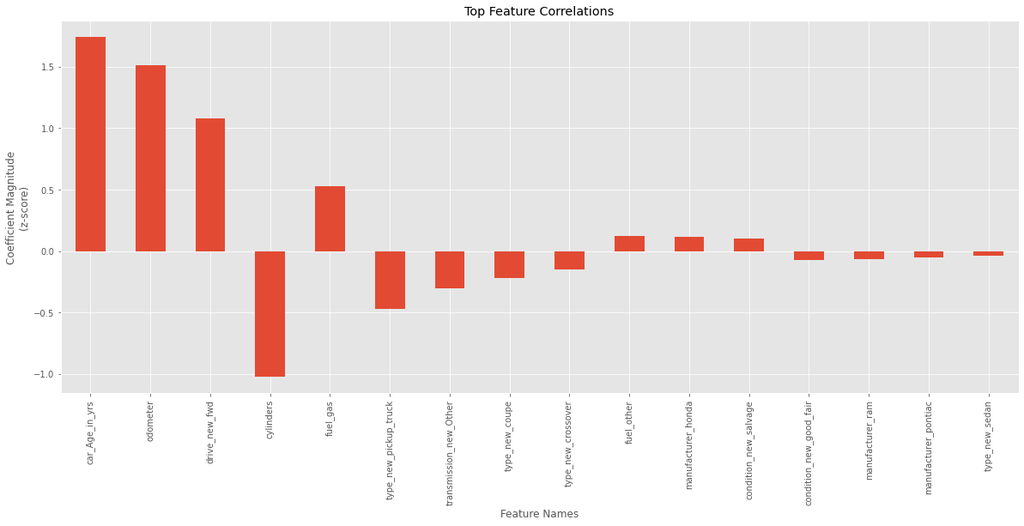

```python
# Examine categorical variables of interest
import matplotlib.pyplot as plt
%matplotlib inline

#Plot the model's feature importances
# REFERENCE:  Eric Larson, https://github.com/eclarson/DataMiningNotebooks
plt.style.use('ggplot')

wt_plt_df = linreg_ft_imp_df.head(75)

weights = pd.Series(wt_plt_df['weights'].values,index=wt_plt_df['feature_names'])
ax = weights.plot(kind='bar', figsize=(20,8))

ax.set_title("Top Feature Correlations")
ax.set_ylabel("Coefficient Magnitude\n(z-score)")
ax.set_xlabel("Feature Names")
plt.show()
```

# coef[3]

```python
# interpret the weights

# iterate over the coefficients
weights = lr_clf.coef_[3] # take transpose to make a column vector
variable_names = ['odometer','car_Age_in_yrs','type_new_pickup_truck','transmission_new_Other','cylinders','drive_new_fwd','type_new_sedan','condition_new_good_fair','fuel_gas','fuel_other','manufacturer_ram','type_new_crossover','type_new_coupe','condition_new_salvage','manufacturer_pontiac','manufacturer_honda']
for coef, name in zip(weights,variable_names):
    print(name, 'has weight of', coef)
```

```
odometer has weight of 0.5568224908581277
car_Age_in_yrs has weight of 0.6117913172122033
type_new_pickup_truck has weight of -0.1973296003814353
transmission_new_Other has weight of 0.1086428946910285
cylinders has weight of -0.5217337145811998
drive_new_fwd has weight of 0.675287469219766
type_new_sedan has weight of -0.23644881553953553
condition_new_good_fair has weight of -0.08474275698166536
fuel_gas has weight of 0.18478169551327447
fuel_other has weight of 0.09334262538519557
manufacturer_ram has weight of -0.03105518817165936
type_new_crossover has weight of -0.15330712347326003
type_new_coupe has weight of -0.147557813879562
condition_new_salvage has weight of 0.04139401394363469
manufacturer_pontiac has weight of -0.06794372340274471
manufacturer_honda has weight of 0.2143535632501949
```

```python
weights = lr_clf.coef_[3]
#weights.shape
feature_names = ['odometer','car_Age_in_yrs','type_new_pickup_truck','transmission_new_Other','cylinders','drive_new_fwd','type_new_sedan','condition_new_good_fair','fuel_gas','fuel_other','manufacturer_ram','type_new_crossover','type_new_coupe','condition_new_salvage','manufacturer_pontiac','manufacturer_honda']
#len(feature_names)
linreg_ft_imp_df = pd.DataFrame({'feature_names':feature_names, 'weights':weights, 'absolute_weights': np.abs(weights)})
linreg_ft_imp_df.sort_values(by='absolute_weights', inplace=True, ascending=False )
```

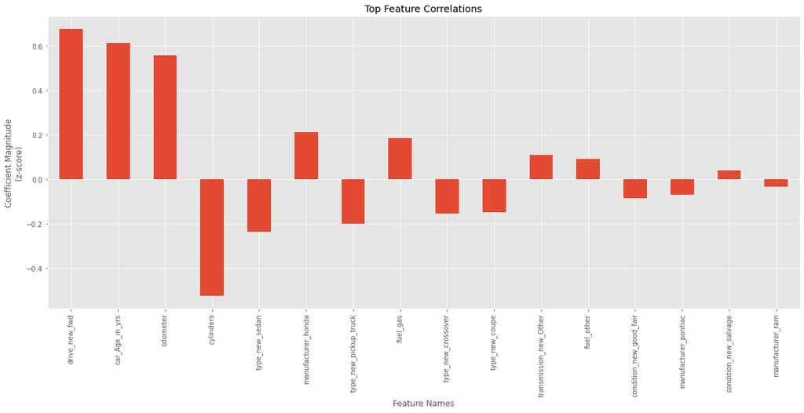

```python
# Examine categorical variables of interest
import matplotlib.pyplot as plt
%matplotlib inline

#Plot the model's feature importances
# REFERENCE:  Eric Larson, https://github.com/eclarson/DataMiningNotebooks
plt.style.use('ggplot')

wt_plt_df = linreg_ft_imp_df.head(75)

weights = pd.Series(wt_plt_df['weights'].values,index=wt_plt_df['feature_names'])
ax = weights.plot(kind='bar', figsize=(20,8))

ax.set_title("Top Feature Correlations")
ax.set_ylabel("Coefficient Magnitude\n(z-score)")
ax.set_xlabel("Feature Names")
plt.show()
```

# coef[4]

```python
# interpret the weights

# iterate over the coefficients
weights = lr_clf.coef_[4] # take transpose to make a column vector
variable_names = ['odometer','car_Age_in_yrs','type_new_pickup_truck','transmission_new_Other','cylinders','drive_new_fwd','type_new_sedan','condition_new_good_fair','fuel_gas','fuel_other','manufacturer_ram','type_new_crossover','type_new_coupe','condition_new_salvage','manufacturer_pontiac','manufacturer_honda']
for coef, name in zip(weights,variable_names):
    print(name, 'has weight of', coef)
```

```
odometer has weight of -0.6559380333905342
car_Age_in_yrs has weight of -0.6794834145529781
type_new_pickup_truck has weight of 0.32101098524970134
transmission_new_Other has weight of 0.26405582735812794
cylinders has weight of 0.19370031419634687
drive_new_fwd has weight of 0.041648885377132974
type_new_sedan has weight of -0.33696714141723744
condition_new_good_fair has weight of -0.053898942856009234
fuel_gas has weight of -0.13366834229900465
fuel_other has weight of -0.033215367667307746
manufacturer_ram has weight of 0.049758057235262464
type_new_crossover has weight of -0.11066804628858874
type_new_coupe has weight of -0.015404269624214675
condition_new_salvage has weight of -0.04044162362341559
manufacturer_pontiac has weight of 0.0754576496644736
manufacturer_honda has weight of 0.30680169143615643
```

```python
weights = lr_clf.coef_[4]
#weights.shape
feature_names = ['odometer','car_Age_in_yrs','type_new_pickup_truck','transmission_new_Other','cylinders','drive_new_fwd','type_new_sedan','condition_new_good_fair','fuel_gas','fuel_other','manufacturer_ram','type_new_crossover','type_new_coupe','condition_new_salvage','manufacturer_pontiac','manufacturer_honda']
#len(feature_names)
linreg_ft_imp_df = pd.DataFrame({'feature_names':feature_names, 'weights':weights, 'absolute_weights': np.abs(weights)})
linreg_ft_imp_df.sort_values(by='absolute_weights', inplace=True, ascending=False )
```

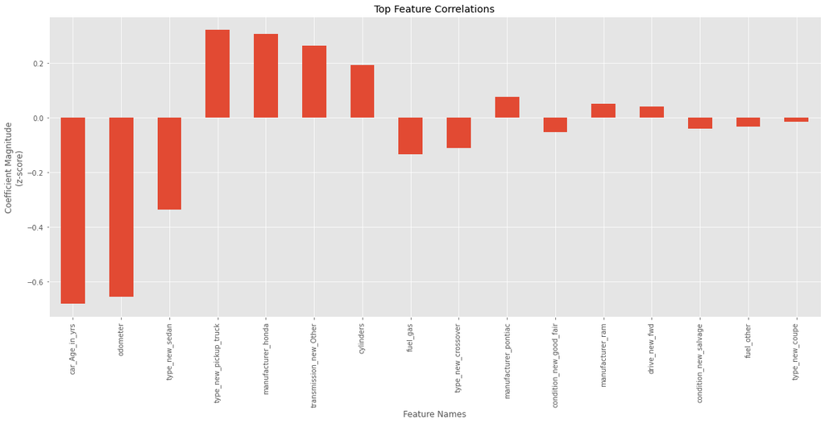

```python
# Examine categorical variables of interest
import matplotlib.pyplot as plt
%matplotlib inline

#Plot the model's feature importances
# REFERENCE:  Eric Larson, https://github.com/eclarson/DataMiningNotebooks
plt.style.use('ggplot')

wt_plt_df = linreg_ft_imp_df.head(75)

weights = pd.Series(wt_plt_df['weights'].values,index=wt_plt_df['feature_names'])
ax = weights.plot(kind='bar', figsize=(20,8))

ax.set_title("Top Feature Correlations")
ax.set_ylabel("Coefficient Magnitude\n(z-score)")
ax.set_xlabel("Feature Names")
plt.show()
```

# coef[5]

```python
# interpret the weights

# iterate over the coefficients
weights = lr_clf.coef_[5] # take transpose to make a column vector
variable_names = ['odometer','car_Age_in_yrs','type_new_pickup_truck','transmission_new_Other','cylinders','drive_new_fwd','type_new_sedan','condition_new_good_fair','fuel_gas','fuel_other','manufacturer_ram','type_new_crossover','type_new_coupe','condition_new_salvage','manufacturer_pontiac','manufacturer_honda']
for coef, name in zip(weights,variable_names):
    print(name, 'has weight of', coef)
```

```
odometer has weight of -2.1404046116840374
car_Age_in_yrs has weight of -2.524519109651917
type_new_pickup_truck has weight of 0.7618900913056461
transmission_new_Other has weight of 0.07633849620660768
cylinders has weight of 1.2940268827703316
drive_new_fwd has weight of -0.9140302699841927
type_new_sedan has weight of -0.21459897216058246
condition_new_good_fair has weight of 0.2369070127522212
fuel_gas has weight of -0.7889221602022944
fuel_other has weight of -0.41308361736775484
manufacturer_ram has weight of -0.003391079330821706
type_new_crossover has weight of 0.1958120924060908
type_new_coupe has weight of 0.15438363882967884
condition_new_salvage has weight of -0.1625369427340657
manufacturer_pontiac has weight of 0.08561803435244
manufacturer_honda has weight of 0.22653668309762665
```

```python
weights = lr_clf.coef_[5]
#weights.shape
feature_names = ['odometer','car_Age_in_yrs','type_new_pickup_truck','transmission_new_Other','cylinders','drive_new_fwd','type_new_sedan','condition_new_good_fair','fuel_gas','fuel_other','manufacturer_ram','type_new_crossover','type_new_coupe','condition_new_salvage','manufacturer_pontiac','manufacturer_honda']
#len(feature_names)
linreg_ft_imp_df = pd.DataFrame({'feature_names':feature_names, 'weights':weights, 'absolute_weights': np.abs(weights)})
linreg_ft_imp_df.sort_values(by='absolute_weights', inplace=True, ascending=False )
```

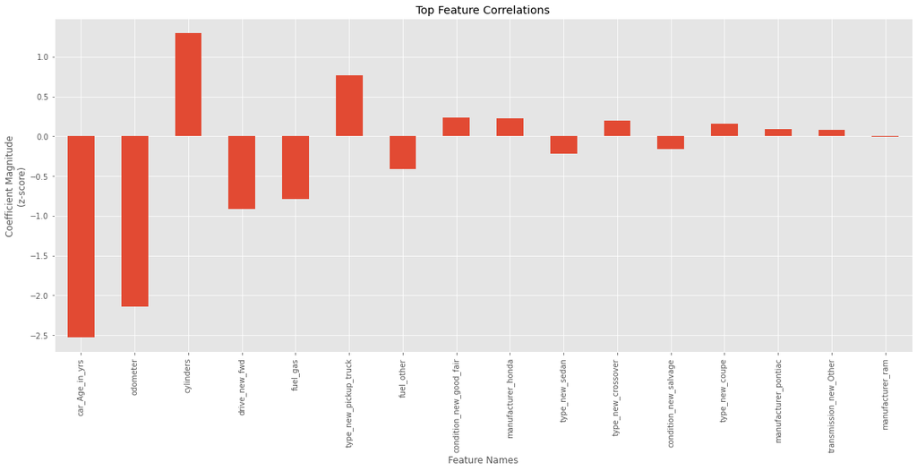

```python
# Examine categorical variables of interest
import matplotlib.pyplot as plt
%matplotlib inline

#Plot the model's feature importances
# REFERENCE:  Eric Larson, https://github.com/eclarson/DataMiningNotebooks
plt.style.use('ggplot')

wt_plt_df = linreg_ft_imp_df.head(75)

weights = pd.Series(wt_plt_df['weights'].values,index=wt_plt_df['feature_names'])
ax = weights.plot(kind='bar', figsize=(20,8))

ax.set_title("Top Feature Correlations")
ax.set_ylabel("Coefficient Magnitude\n(z-score)")
ax.set_xlabel("Feature Names")
plt.show()
```

# coef[6]

```python
# interpret the weights

# iterate over the coefficients
weights = lr_clf.coef_[6] # take transpose to make a column vector
variable_names = ['odometer','car_Age_in_yrs','type_new_pickup_truck','transmission_new_Other','cylinders','drive_new_fwd','type_new_sedan','condition_new_good_fair','fuel_gas','fuel_other','manufacturer_ram','type_new_crossover','type_new_coupe','condition_new_salvage','manufacturer_pontiac','manufacturer_honda']
for coef, name in zip(weights,variable_names):
    print(name, 'has weight of', coef)
```

```
odometer has weight of -3.183664596344706
car_Age_in_yrs has weight of -3.7884979565935484
type_new_pickup_truck has weight of 0.8880656560261967
transmission_new_Other has weight of -0.10079490061692686
cylinders has weight of 1.867417977025011
drive_new_fwd has weight of -3.562145107268901
type_new_sedan has weight of 0.519171457032738
condition_new_good_fair has weight of -0.4037798978198023
fuel_gas has weight of -1.3801419262801242
fuel_other has weight of -0.5083568419042772
manufacturer_ram has weight of 0.008108025504011311
type_new_crossover has weight of 0.5001784784027076
type_new_coupe has weight of 0.46689852498248957
condition_new_salvage has weight of -0.35864657694851154
manufacturer_pontiac has weight of -0.11075199351906567
manufacturer_honda has weight of -0.9778227006561239
```

```python
weights = lr_clf.coef_[6]
#weights.shape
feature_names = ['odometer','car_Age_in_yrs','type_new_pickup_truck','transmission_new_Other','cylinders','drive_new_fwd','type_new_sedan','condition_new_good_fair','fuel_gas','fuel_other','manufacturer_ram','type_new_crossover','type_new_coupe','condition_new_salvage','manufacturer_pontiac','manufacturer_honda']
#len(feature_names)
linreg_ft_imp_df = pd.DataFrame({'feature_names':feature_names, 'weights':weights, 'absolute_weights': np.abs(weights)})
linreg_ft_imp_df.sort_values(by='absolute_weights', inplace=True, ascending=False )
```

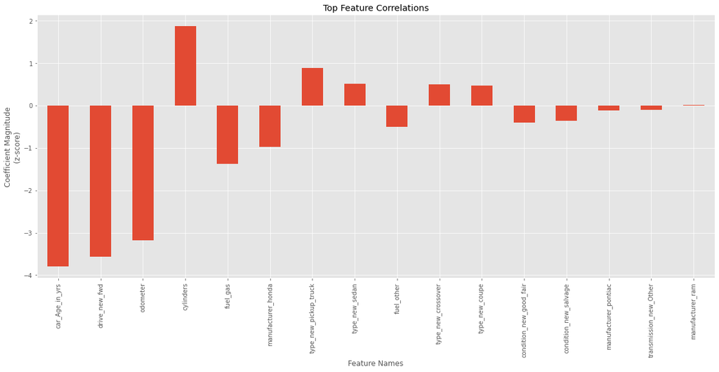

```python
# Examine categorical variables of interest
import matplotlib.pyplot as plt
%matplotlib inline

#Plot the model's feature importances
# REFERENCE:  Eric Larson, https://github.com/eclarson/DataMiningNotebooks
plt.style.use('ggplot')

wt_plt_df = linreg_ft_imp_df.head(75)

weights = pd.Series(wt_plt_df['weights'].values,index=wt_plt_df['feature_names'])
ax = weights.plot(kind='bar', figsize=(20,8))

ax.set_title("Top Feature Correlations")
ax.set_ylabel("Coefficient Magnitude\n(z-score)")
ax.set_xlabel("Feature Names")
plt.show()
```

## LR with PCA

```python
%%time
#PCA with 50 components
from sklearn.decomposition import PCA
n_components = 50
cv = StratifiedShuffleSplit( n_splits=3,test_size=0.2, random_state=42)

pca = PCA(n_components=n_components, svd_solver='randomized')

iterations = 150
log_sgd = SGDClassifier(
        fit_intercept=True, l1_ratio=0.0, learning_rate='optimal',
        loss='log', n_iter_no_change=iterations, n_jobs=-1, penalty='l2')

# you could also set this up in a pipeline
scl = StandardScaler()
for train_idx, test_idx in cv.split(X,y):
    log_sgd.fit(pca.fit_transform(X[train_idx]),y[train_idx])
    yhat = log_sgd.predict(pca.transform(X[test_idx]))

    conf = mt.confusion_matrix(y[test_idx],yhat)
    acc = mt.accuracy_score(y[test_idx],yhat)


print('Logistic Regression:', acc)
print(conf)
```

```
Logistic Regression: 0.13764269613902422
[[   0   19  173    0  282    0    0]
 [   0  310  359    0 4446    0    0]
 [   0  284 1902    0 4729    0    0]
 [   0  101 2694    0 1898    0    0]
 [   0   73 5820    0 1574    0    0]
 [   0   14 2565    0  226    0    0]
 [   0    0   36    0    1    0    0]]
Wall time: 8min 23s
```

```python
%%time
#PCA with 37 components
n_components = 37

pca = PCA(n_components=n_components, svd_solver='randomized')

iterations = 150
log_sgd = SGDClassifier(
        fit_intercept=True, l1_ratio=0.0, learning_rate='optimal',
        loss='log', n_iter_no_change=iterations, n_jobs=-1, penalty='l2')

# you could also set this up in a pipeline
scl = StandardScaler()
for train_idx, test_idx in cv.split(X,y):
    log_sgd.fit(pca.fit_transform(X[train_idx]),y[train_idx])
    yhat = log_sgd.predict(pca.transform(X[test_idx]))

    conf = mt.confusion_matrix(y[test_idx],yhat)
    acc = mt.accuracy_score(y[test_idx],yhat)


print('Logistic Regression:', acc)
print(conf)
```

```
Logistic Regression: 0.2839016941758162
[[   0  280    0  184   10    0    0]
 [   0 4559   36  503   17    0    0]
 [   0 4531  202 2017  165    0    0]
 [   0 1685  102 2708  198    0    0]
 [   0 1260   35 5830  340    2    0]
 [   0  152    0 2568   85    0    0]
 [   0    1    0   36    0    0    0]]
Wall time: 6min 4s
```

## SVM

```python
#copy clean data to car_df
car_df_svm = car_df.copy()
```

```python
#convert price range to integers 1 - 7
car_df_svm['price_range'].replace(to_replace=['<1K', '1K-5K', '5K-10K','10K-15K','15k-30K','30K-50K','>50K'], value=[1, 2, 3, 4, 5, 6, 7], inplace=True)
car_df_svm = car_df_svm.rename(columns={'price_range': 'price_range_int'})
car_df_svm.info()
```

```
<class 'pandas.core.frame.DataFrame'>
RangeIndex: 137526 entries, 0 to 137525
Data columns (total 14 columns):
 #   Column            Non-Null Count   Dtype
---  ------            --------------   -----
 0   manufacturer      137526 non-null  object
 1   cylinders         137526 non-null  int64
 2   fuel              137526 non-null  object
 3   odometer          137526 non-null  float64
 4   title_status      137526 non-null  object
 5   state             137526 non-null  object
 6   price_range_int   137526 non-null  int64
 7   drive_new         137526 non-null  object
 8   condition_new     137526 non-null  object
 9   transmission_new  137526 non-null  object
 10  type_new          137526 non-null  object
 11  paint_color_new   137526 non-null  object
 12  car_Age_in_yrs    137526 non-null  float64
 13  price_range_int   137526 non-null  int32
dtypes: float64(2), int32(1), int64(2), object(9)
memory usage: 14.2+ MB
```

```python
#new df with categorical variables one hot encoded, all variables
car_df_ohe = pd.get_dummies(car_df[['manufacturer',
                                         'cylinders',
                                         'fuel',
                                         'odometer',
                                         'title_status',
                                          'state',
                                         'drive_new',
                                         'condition_new',
                                         'transmission_new',
                                         'type_new',
                                         'paint_color_new',
                                         'car_Age_in_yrs',
                                           'price_range_int']])
```

```python
#top 103 columns from feature selection
top103 = ['price_range_int','type_new_sedan', 'state_hi', 'type_new_van', 'type_new_pickup_truck', 'state_in', 'state_il', 'state_id', 'paint_color_new_OrYlwGrnPrpl', 'state_al', 'state_ga', 'state_az', 'state_fl', 'state_de', 'paint_color_new_BluRdBrwn', 'state_dc', 'state_ar', 'state_ct', 'state_co', 'cylinders', 'state_mn', 'state_ma', 'state_oh', 'state_wv', 'state_vt', 'state_va', 'state_ut', 'state_tx', 'state_sd', 'state_sc', 'state_ri', 'state_pa', 'state_or', 'state_ny', 'state_me', 'state_nv', 'state_nj', 'state_nh', 'state_ne', 'state_nd', 'state_nc', 'state_mt', 'state_ms', 'type_new_mini-van', 'state_mi', 'type_new_offroad', 'type_new_coupe', 'type_new_hatchback', 'manufacturer_mitsubishi', 'manufacturer_mercury', 'manufacturer_mercedes-benz', 'manufacturer_mazda', 'manufacturer_lincoln', 'manufacturer_lexus', 'manufacturer_land rover', 'manufacturer_kia', 'manufacturer_jeep', 'manufacturer_jaguar', 'manufacturer_infiniti', 'manufacturer_hyundai', 'manufacturer_honda', 'manufacturer_harley-davidson', 'manufacturer_gmc', 'manufacturer_ford', 'manufacturer_fiat', 'manufacturer_dodge', 'manufacturer_chrysler', 'manufacturer_chevrolet', 'manufacturer_cadillac', 'manufacturer_buick', 'manufacturer_bmw', 'manufacturer_audi', 'manufacturer_alfa-romeo', 'car_Age_in_yrs', 'manufacturer_mini', 'manufacturer_nissan', 'type_new_crossover', 'manufacturer_pontiac', 'odometer', 'transmission_new_Other', 'transmission_new_Manual', 'condition_new_salvage', 'condition_new_good_fair', 'drive_new_rwd', 'drive_new_fwd', 'title_status_salvage', 'title_status_rebuilt', 'title_status_parts only', 'title_status_missing', 'fuel_other', 'fuel_hybrid', 'fuel_gas', 'fuel_electric', 'manufacturer_volvo', 'manufacturer_volkswagen', 'manufacturer_toyota', 'manufacturer_tesla', 'manufacturer_subaru', 'manufacturer_saturn', 'manufacturer_rover', 'manufacturer_ram', 'manufacturer_porsche', 'state_wy']

#ohe df with only top 60 features + cyclinders, car age, and odometer
car_df_ohe = car_df_ohe[top103]
```

```python
#top 60 columns from feature selection
top60 = ['price_range_int','cylinders','odometer','car_Age_in_yrs','manufacturer_alfa-romeo','manufacturer_audi','manufacturer_bmw','manufacturer_buick','manufacturer_cadillac','manufacturer_chevrolet','manufacturer_chrysler','manufacturer_dodge','manufacturer_ford','manufacturer_fiat','manufacturer_gmc','manufacturer_harley-davidson','manufacturer_honda','manufacturer_hyundai','manufacturer_infiniti','manufacturer_jeep','manufacturer_jaguar','manufacturer_kia','manufacturer_land rover','manufacturer_lexus','manufacturer_lincoln','manufacturer_mazda','manufacturer_mercury','manufacturer_mercedes-benz','manufacturer_mini','manufacturer_mitsubishi','manufacturer_nissan','manufacturer_pontiac','manufacturer_porsche','manufacturer_ram','manufacturer_rover','manufacturer_toyota','manufacturer_volkswagen','manufacturer_subaru','manufacturer_tesla','manufacturer_saturn','fuel_electric','manufacturer_volvo','fuel_gas','fuel_hybrid','fuel_other','title_status_missing','title_status_parts only','title_status_salvage','title_status_rebuilt','drive_new_fwd','condition_new_good_fair','drive_new_rwd','condition_new_salvage','transmission_new_Manual','transmission_new_Other','type_new_coupe','type_new_hatchback','type_new_crossover','type_new_mini-van','paint_color_new_BluRdBrwn']

#ohe df with only top 60 features + cyclinders, car age, and odometer
car_df_ohe_top60 = car_df_ohe[top60]
```

```python
#top 30 columns from feature selection
top30 = ['price_range_int','cylinders','odometer','car_Age_in_yrs','manufacturer_alfa-romeo','manufacturer_audi','manufacturer_bmw','manufacturer_buick','manufacturer_cadillac','manufacturer_chevrolet','manufacturer_chrysler','manufacturer_dodge','manufacturer_ford','manufacturer_fiat','manufacturer_gmc','manufacturer_harley-davidson','manufacturer_honda','manufacturer_hyundai','manufacturer_infiniti','manufacturer_jeep','manufacturer_jaguar','manufacturer_kia','manufacturer_land rover','manufacturer_lexus','manufacturer_lincoln','manufacturer_mazda','manufacturer_mercury','manufacturer_mercedes-benz','manufacturer_mini','manufacturer_mitsubishi','manufacturer_nissan']

#ohe df with only top 30 features + cyclinders, car age, and odometer
car_df_ohe_top30 = car_df_ohe[top30]
```

```python
#top 20 columns from feature selection
top20 = ['price_range_int','cylinders','odometer','car_Age_in_yrs','manufacturer_alfa-romeo','manufacturer_audi','manufacturer_bmw','manufacturer_buick','manufacturer_cadillac','manufacturer_chevrolet','manufacturer_chrysler','manufacturer_dodge','manufacturer_ford','manufacturer_fiat','manufacturer_gmc','manufacturer_harley-davidson','manufacturer_honda','manufacturer_hyundai','manufacturer_infiniti','manufacturer_jeep','manufacturer_jaguar']

#ohe df with only top 30 features + cyclinders, car age, and odometer
car_df_ohe_top20 = car_df_ohe[top20]
```

```python
#top columns from Kbest feature selection
kbest = ['price_range_int', 'odometer','car_Age_in_yrs','type_new_pickup_truck','transmission_new_Other','cylinders','drive_new_fwd','type_new_sedan','condition_new_good_fair','fuel_gas','fuel_other','manufacturer_ram','type_new_crossover','type_new_coupe','condition_new_salvage','manufacturer_pontiac','manufacturer_honda']
#ohe df with only top 30 features + cyclinders, car age, and odometer
car_df_ohe_kbest = car_df_ohe[kbest]
```

```python
#separate into X, y - all columns, used for 103 selected features from rfe.
y = car_df_ohe['price_range_int'].values
del car_df_ohe['price_range_int']
X = car_df_ohe.values
```

```python
#separate into X, y - top 60 features
y_60 = car_df_ohe_top60['price_range_int'].values
del car_df_ohe_top60['price_range_int']
X_60 = car_df_ohe_top60.values
```

```python
#separate into X, y - top 30 features
y_30 = car_df_ohe_top30['price_range_int'].values
del car_df_ohe_top30['price_range_int']
X_30 = car_df_ohe_top30.values
```

```python
#separate into X, y - top 20 features
y_20 = car_df_ohe_top20['price_range_int'].values
del car_df_ohe_top20['price_range_int']
X_20 = car_df_ohe_top20.values
```

```python
#separate into X, y - K best
y_kbest = car_df_ohe_kbest['price_range_int'].values
del car_df_ohe_kbest['price_range_int']
X_kbest = car_df_ohe_kbest.values
```

```python
# create a Standard Scalar
scl = StandardScaler()

#set up cv object with stratified shuffle split and test_size of 0.2
num_cv_iterations = 10
cv = StratifiedShuffleSplit(n_splits=num_cv_iterations, random_state=42, test_size=0.2)
print(cv)
```

```
StratifiedShuffleSplit(n_splits=10, random_state=42, test_size=0.2,
            train_size=None)
```

```python
#set the scoring parameters
scorer = {'accuracy': make_scorer(accuracy_score),
                 'precision': make_scorer(precision_score, average='weighted',zero_division=0),
                 'recall': make_scorer(recall_score, average='weighted', zero_division=0)
                 }
```

```python
#create an estimator for scoring
#reference for Dr. Drew's code: https://nbviewer.jupyter.org/github/jakemdrew/EducationDataNC/blob/master/2017/Models/2017ComparingSegregatedHighSchoolCampuses.ipynb
def EvaluateClassifierEstimator(classifierEstimator, X, y, cv, score_params):

    #Perform cross validation
    scores = cross_validate(classifierEstimator, X, y, scoring=score_params, cv=cv, return_train_score=True)

    Accavg = scores['test_accuracy'].mean()
    Preavg = scores['test_precision'].mean()
    Recavg = scores['test_recall'].mean()

    print_str = "The average accuracy for all cv folds is: \t\t\t {Accavg:.5}"
    print_str2 = "The average precision for all cv folds is: \t\t\t {Preavg:.5}"
    print_str3 = "The average recall for all cv folds is: \t\t\t {Recavg:.5}"

    print(print_str.format(Accavg=Accavg))
    print(print_str2.format(Preavg=Preavg))
    print(print_str3.format(Recavg=Recavg))
    print('*********************************************************')

    print('Cross Validation Fold Mean Error Scores')
    scoresResults = pd.DataFrame()
    scoresResults['Accuracy'] = scores['test_accuracy']
    scoresResults['Precision'] = scores['test_precision']
    scoresResults['Recall'] = scores['test_recall']

    return scoresResults
```

### SVM: Stochastic Gradient Descent

#### SGD: 103 predictors selected from rfe, all records

```python
#linear SVM classifier with stochastic descent
regularize_const = 0.1
iterations = 5
svm_sgd = SGDClassifier(alpha=regularize_const,
        fit_intercept=True, l1_ratio=0.0, learning_rate='optimal',
        loss='hinge', n_iter_no_change=iterations, n_jobs=-1, penalty='l2')
```

```python
%%time

#evaluate the stochastic gradient descent model
EvaluateClassifierEstimator(svm_sgd, scl.fit_transform(X), y, cv, scorer)
```

```
The average accuracy for all cv folds is: 			 0.51969
The average precision for all cv folds is: 			 0.5224
The average recall for all cv folds is: 			 0.51969
Cross Validation Fold Mean Error Scores
Wall time: 17.1 s
```

|  | Accuracy | Precision | Recall |
| --- | --- | --- | --- |
| 0 | 0.520250 | 0.509503 | 0.520250 |
| 1 | 0.513379 | 0.529229 | 0.513379 |
| 2 | 0.526140 | 0.519111 | 0.526140 |
| 3 | 0.520795 | 0.533217 | 0.520795 |
| 4 | 0.514361 | 0.521035 | 0.514361 |
| 5 | 0.519087 | 0.516196 | 0.519087 |
| 6 | 0.518541 | 0.519983 | 0.518541 |
| 7 | 0.518069 | 0.521630 | 0.518069 |
| 8 | 0.522613 | 0.520752 | 0.522613 |
| 9 | 0.523668 | 0.533375 | 0.523668 |

#### SGD: Top 60 predictors, all records

```python
#create SGD classifier
svm_sgd_60 = SGDClassifier(alpha=regularize_const,
        fit_intercept=True, l1_ratio=0.0, learning_rate='optimal',
        loss='hinge', n_iter_no_change=iterations, n_jobs=-1, penalty='l2')
```

```python
%%time

#evaluate the stochastic gradient descent model
EvaluateClassifierEstimator(svm_sgd_60, scl.fit_transform(X_60), y_60, cv, scorer)
```

```
The average accuracy for all cv folds is: 			 0.51419
The average precision for all cv folds is: 			 0.50946
The average recall for all cv folds is: 			 0.51419
Cross Validation Fold Mean Error Scores
Wall time: 12.6 s
```

|  | Accuracy | Precision | Recall |
| --- | --- | --- | --- |
| 0 | 0.502036 | 0.503675 | 0.502036 |
| 1 | 0.514542 | 0.520397 | 0.514542 |
| 2 | 0.521777 | 0.513658 | 0.521777 |
| 3 | 0.513015 | 0.501413 | 0.513015 |
| 4 | 0.509234 | 0.507868 | 0.509234 |
| 5 | 0.521414 | 0.511086 | 0.521414 |
| 6 | 0.514288 | 0.519909 | 0.514288 |
| 7 | 0.511816 | 0.497025 | 0.511816 |
| 8 | 0.516360 | 0.503654 | 0.516360 |
| 9 | 0.517414 | 0.515964 | 0.517414 |

#### SGD: Top 30 predictors, all records

```python
#create SGD classifier
svm_sgd_30 = SGDClassifier(alpha=regularize_const,
        fit_intercept=True, l1_ratio=0.0, learning_rate='optimal',
        loss='hinge', n_iter_no_change=iterations, n_jobs=-1, penalty='l2')
```

```python
# %%time

#evaluate the stochastic gradient descent model
EvaluateClassifierEstimator(svm_sgd_30, scl.fit_transform(X_30), y_30, cv, scorer)
```

```
The average accuracy for all cv folds is: 			 0.48228
The average precision for all cv folds is: 			 0.45322
The average recall for all cv folds is: 			 0.48228
Cross Validation Fold Mean Error Scores
```

|  | Accuracy | Precision | Recall |
| --- | --- | --- | --- |
| 0 | 0.478259 | 0.446161 | 0.478259 |
| 1 | 0.467643 | 0.421177 | 0.467643 |
| 2 | 0.483931 | 0.454394 | 0.483931 |
| 3 | 0.484512 | 0.448892 | 0.484512 |
| 4 | 0.487021 | 0.458008 | 0.487021 |
| 5 | 0.492983 | 0.464597 | 0.492983 |
| 6 | 0.487021 | 0.468962 | 0.487021 |
| 7 | 0.482658 | 0.451003 | 0.482658 |
| 8 | 0.488330 | 0.463644 | 0.488330 |
| 9 | 0.470406 | 0.455402 | 0.470406 |

#### SGD: Top 20 predictors, all records

```python
#create SGD classifier
svm_sgd_20 = SGDClassifier(alpha=regularize_const,
        fit_intercept=True, l1_ratio=0.0, learning_rate='optimal',
        loss='hinge', n_iter_no_change=iterations, n_jobs=-1, penalty='l2')
```

```python
# %%time

#evaluate the stochastic gradient descent model
EvaluateClassifierEstimator(svm_sgd_20, scl.fit_transform(X_20), y_20, cv, scorer)
```

```
The average accuracy for all cv folds is: 			 0.47423
The average precision for all cv folds is: 			 0.44485
The average recall for all cv folds is: 			 0.47423
Cross Validation Fold Mean Error Scores
```

|  | Accuracy | Precision | Recall |
| --- | --- | --- | --- |
| 0 | 0.465898 | 0.429993 | 0.465898 |
| 1 | 0.473642 | 0.448962 | 0.473642 |
| 2 | 0.469570 | 0.430872 | 0.469570 |
| 3 | 0.478441 | 0.439646 | 0.478441 |
| 4 | 0.476551 | 0.456819 | 0.476551 |
| 5 | 0.486148 | 0.449027 | 0.486148 |
| 6 | 0.474587 | 0.454885 | 0.474587 |
| 7 | 0.476296 | 0.451324 | 0.476296 |
| 8 | 0.472152 | 0.440701 | 0.472152 |
| 9 | 0.469061 | 0.446300 | 0.469061 |

#### SGD: KBest predictors, all records

```python
#create SGD classifier
svm_sgd_kbest = SGDClassifier(alpha=regularize_const,
        fit_intercept=True, l1_ratio=0.0, learning_rate='optimal',
        loss='hinge', n_iter_no_change=iterations, n_jobs=-1, penalty='l2')
```

```python
# %%time

#evaluate the stochastic gradient descent model
EvaluateClassifierEstimator(svm_sgd_kbest, scl.fit_transform(X_kbest), y_kbest, cv, scorer)
```

```
The average accuracy for all cv folds is: 			 0.51414
The average precision for all cv folds is: 			 0.4959
The average recall for all cv folds is: 			 0.51414
Cross Validation Fold Mean Error Scores
```

|  | Accuracy | Precision | Recall |
| --- | --- | --- | --- |
| 0 | 0.515960 | 0.501539 | 0.515960 |
| 1 | 0.506871 | 0.497242 | 0.506871 |
| 2 | 0.510798 | 0.489593 | 0.510798 |
| 3 | 0.522141 | 0.523778 | 0.522141 |
| 4 | 0.501200 | 0.470822 | 0.501200 |
| 5 | 0.517378 | 0.505844 | 0.517378 |
| 6 | 0.516251 | 0.482952 | 0.516251 |
| 7 | 0.522613 | 0.495871 | 0.522613 |
| 8 | 0.514979 | 0.503933 | 0.514979 |
| 9 | 0.513197 | 0.487423 | 0.513197 |

### Support Vector Machines

Random Sampling:</b> Due to the large number of samples in the dataset, random sampling will be used to reduce the processing time to run a GridSearch and the SVC model.

```python
#random sample from the dataset setting the weights to the price_range
car_df_30k = car_df.sample(n=30000, weights='price_range_int', random_state=42)
```

```python
#counts in each price_range
car_df_30k['price_range_int'].value_counts()
```

```
5    10374
3     6219
4     5400
6     4587
2     3218
1      140
7       62
Name: price_range_int, dtype: int64
```

```python
#ohe - all features
car_df_ohe_30k = pd.get_dummies(car_df_30k[['manufacturer',
                                         'cylinders',
                                         'fuel',
                                         'odometer',
                                         'title_status',
                                          'state',
                                         'drive_new',
                                         'condition_new',
                                         'transmission_new',
                                         'type_new',
                                         'paint_color_new',
                                         'car_Age_in_yrs',
                                           'price_range_int']])
```

```python
#ohe df with only top 60 features + cyclinders, car age, and odometer
car_df_ohe_30k_top103 = car_df_ohe_30k[top103]

#ohe df with only top 60 features + cyclinders, car age, and odometer
car_df_ohe_30k_top60 = car_df_ohe_30k[top60]

#ohe df with only top 30 features + cyclinders, car age, and odometer
car_df_ohe_30k_top30 = car_df_ohe_30k[top30]

#ohe df with only top 20 features + cyclinders, car age, and odometer
car_df_ohe_30k_top20 = car_df_ohe_30k[top20]

#ohe df with only top 20 features + cyclinders, car age, and odometer
car_df_ohe_30k_kbest = car_df_ohe_30k[kbest]
```

```python
#separate df into X, y - all features
y_30k = car_df_ohe_30k_top103['price_range_int'].values
del car_df_ohe_30k_top103['price_range_int']
X_30k = car_df_ohe_30k_top103.values

#separate into X, y - top 60 features
y_30k_60 = car_df_ohe_30k_top60['price_range_int'].values
del car_df_ohe_30k_top60['price_range_int']
X_30k_60 = car_df_ohe_30k_top60.values

#separate into X, y - top 30 features
y_30k_30 = car_df_ohe_30k_top30['price_range_int'].values
del car_df_ohe_30k_top30['price_range_int']
X_30k_30 = car_df_ohe_30k_top30.values

#separate into X, y - top 20 features
y_30k_20 = car_df_ohe_30k_top20['price_range_int'].values
del car_df_ohe_30k_top20['price_range_int']
X_30k_20 = car_df_ohe_30k_top20.values

#separate into X, y - top 20 features
y_30k_kbest = car_df_ohe_30k_kbest['price_range_int'].values
del car_df_ohe_30k_kbest['price_range_int']
X_30k_kbest = car_df_ohe_30k_kbest.values
```

```python
#svm gridsearch: hyperparameter search to find the best combination of parameters for the data
#reference - Dr. Drew's code: nbviewer.jupyter.org/github/jakemdrew/EducationDataNC/blob/master/2017/Models/2017ComparingSegregatedHighSchoolCampuses.ipynb

#set up the svm with kernel='rbf'
svm_clf_gs = SVC(kernel='rbf')

#set parameters for the gridsearch
parameters = { 'C': [0.1, 1,10,100],
              'gamma': ['auto','scaled'],
              'class_weight': ['balanced'],
              'random_state': [42],
              'decision_function_shape':['ovo']
             }
```

```python
#grid search
svm_grid_search = GridSearchCV(estimator=svm_clf_gs,
                             n_jobs=16, #jobs to run in parallel
                             verbose=1, #low verbosity
                             param_grid=parameters,#set above
                             cv=cv, #kfolds set above
                             scoring='accuracy')
```

```python
%%time
#fit with the randomly selected data
#svm_grid_search.fit(scl.fit_transform(X_30k), y_30k)
```

```
Wall time: 0 ns
```

```python
#results of the gridsearch
#svm_clf = svm_grid_search.best_estimator_
svm_clf = SVC(C=100, class_weight='balanced', decision_function_shape='ovo', gamma='auto',random_state=42)
print(svm_clf)
```

```
SVC(C=100, class_weight='balanced', decision_function_shape='ovo', gamma='auto',
    random_state=42)
```

#### SVM: Top 103 features, 30k records

```python
%%time
#Evaluate the estimator
EvaluateClassifierEstimator(svm_clf, scl.fit_transform(X_30k), y_30k, cv, scorer)
```

```
The average accuracy for all cv folds is: 			 0.68698
The average precision for all cv folds is: 			 0.69413
The average recall for all cv folds is: 			 0.68698
Cross Validation Fold Mean Error Scores
Wall time: 29min 18s
```

|  | Accuracy | Precision | Recall |
| --- | --- | --- | --- |
| 0 | 0.684167 | 0.690030 | 0.684167 |
| 1 | 0.685500 | 0.695828 | 0.685500 |
| 2 | 0.692667 | 0.700408 | 0.692667 |
| 3 | 0.690333 | 0.696773 | 0.690333 |
| 4 | 0.683000 | 0.690944 | 0.683000 |
| 5 | 0.688333 | 0.694935 | 0.688333 |
| 6 | 0.677167 | 0.683718 | 0.677167 |
| 7 | 0.690667 | 0.699346 | 0.690667 |
| 8 | 0.690833 | 0.696282 | 0.690833 |
| 9 | 0.687167 | 0.693028 | 0.687167 |

#### SVM: Top 60 features, 30k records

```python
%%time
#Evaluate the estimator
EvaluateClassifierEstimator(svm_clf, scl.fit_transform(X_30k_60), y_30k_60, cv, scorer)
```

```
The average accuracy for all cv folds is: 			 0.70065
The average precision for all cv folds is: 			 0.72537
The average recall for all cv folds is: 			 0.70065
Cross Validation Fold Mean Error Scores
Wall time: 17min 45s
```

|  | Accuracy | Precision | Recall |
| --- | --- | --- | --- |
| 0 | 0.703500 | 0.727901 | 0.703500 |
| 1 | 0.703000 | 0.728615 | 0.703000 |
| 2 | 0.700167 | 0.725323 | 0.700167 |
| 3 | 0.702500 | 0.727775 | 0.702500 |
| 4 | 0.697333 | 0.721360 | 0.697333 |
| 5 | 0.701167 | 0.726058 | 0.701167 |
| 6 | 0.699167 | 0.725665 | 0.699167 |
| 7 | 0.702333 | 0.727498 | 0.702333 |
| 8 | 0.702833 | 0.725276 | 0.702833 |
| 9 | 0.694500 | 0.718218 | 0.694500 |

#### SVM: Top 30 features, 30k records

```python
%%time
#Evaluate the estimator
EvaluateClassifierEstimator(svm_clf, scl.fit_transform(X_30k_30), y_30k_30, cv, scorer)
```

```
The average accuracy for all cv folds is: 			 0.54683
The average precision for all cv folds is: 			 0.6386
The average recall for all cv folds is: 			 0.54683
Cross Validation Fold Mean Error Scores
Wall time: 16min 44s
```

|  | Accuracy | Precision | Recall |
| --- | --- | --- | --- |
| 0 | 0.541167 | 0.641608 | 0.541167 |
| 1 | 0.539333 | 0.638014 | 0.539333 |
| 2 | 0.553833 | 0.642314 | 0.553833 |
| 3 | 0.556833 | 0.647469 | 0.556833 |
| 4 | 0.538333 | 0.634608 | 0.538333 |
| 5 | 0.544833 | 0.636272 | 0.544833 |
| 6 | 0.537500 | 0.629140 | 0.537500 |
| 7 | 0.561000 | 0.645901 | 0.561000 |
| 8 | 0.551167 | 0.636149 | 0.551167 |
| 9 | 0.544333 | 0.634559 | 0.544333 |

#### SVM: Top 20 features, 30k records

```python
%%time
#Evaluate the estimator
EvaluateClassifierEstimator(svm_clf, scl.fit_transform(X_30k_20), y_30k_20, cv, scorer)
```

```
The average accuracy for all cv folds is: 			 0.5392
The average precision for all cv folds is: 			 0.62198
The average recall for all cv folds is: 			 0.5392
Cross Validation Fold Mean Error Scores
Wall time: 13min 56s
```

|  | Accuracy | Precision | Recall |
| --- | --- | --- | --- |
| 0 | 0.533500 | 0.623332 | 0.533500 |
| 1 | 0.533833 | 0.617442 | 0.533833 |
| 2 | 0.541500 | 0.625873 | 0.541500 |
| 3 | 0.547167 | 0.630949 | 0.547167 |
| 4 | 0.530000 | 0.617073 | 0.530000 |
| 5 | 0.530167 | 0.611744 | 0.530167 |
| 6 | 0.536500 | 0.620169 | 0.536500 |
| 7 | 0.553667 | 0.628269 | 0.553667 |
| 8 | 0.545667 | 0.622149 | 0.545667 |
| 9 | 0.540000 | 0.622831 | 0.540000 |

#### SVM: K-best features, 30k records

```python
%%time
#Evaluate the estimator
EvaluateClassifierEstimator(svm_clf, scl.fit_transform(X_30k_kbest), y_30k_kbest, cv, scorer)
```

```
The average accuracy for all cv folds is: 			 0.62722
The average precision for all cv folds is: 			 0.67459
The average recall for all cv folds is: 			 0.62722
Cross Validation Fold Mean Error Scores
Wall time: 9min 51s
```

|  | Accuracy | Precision | Recall |
| --- | --- | --- | --- |
| 0 | 0.628000 | 0.676703 | 0.628000 |
| 1 | 0.620167 | 0.665066 | 0.620167 |
| 2 | 0.621833 | 0.671066 | 0.621833 |
| 3 | 0.625167 | 0.675570 | 0.625167 |
| 4 | 0.624667 | 0.672210 | 0.624667 |
| 5 | 0.624500 | 0.676358 | 0.624500 |
| 6 | 0.632333 | 0.677230 | 0.632333 |
| 7 | 0.621000 | 0.672690 | 0.621000 |
| 8 | 0.634500 | 0.676927 | 0.634500 |
| 9 | 0.640000 | 0.682034 | 0.640000 |

## SVM kde

```python
svm_clf3 = SVC(C=100, class_weight='balanced', decision_function_shape='ovo', gamma='auto',random_state=42)
#svm_clf3 = svm_grid_search.best_estimator_
print(svm_clf3)
```

```
SVC(C=100, class_weight='balanced', decision_function_shape='ovo', gamma='auto',
    random_state=42)
```

```python
%%time

#reference:  https://nbviewer.jupyter.org/github/jakemdrew/DataMiningNotebooks/blob/master/04.%20Logits%20and%20SVM.ipynb

#use the cv object to iterate through different training and testing sets. Each time we will reuse the svm
#object, but it gets trained on different data each time we use it.
iter_num=0
for train_idx, test_idx in cv.split(X_30k,y_30k):
    svm_clf3.fit(scl.fit_transform(X_30k[train_idx]),y_30k[train_idx])
    y_hat3 = svm_clf3.predict(scl.fit_transform(X_30k[test_idx]))
    acc3= mt.accuracy_score(y_30k[test_idx],y_hat3)
    conf3= mt.confusion_matrix(y_30k[test_idx],y_hat3)
    print("====Iteration",iter_num," ====")
    print("accuracy", acc3)
    print("confusion matrix\n",conf3)
    print(classification_report(y_30k[test_idx], y_hat3, zero_division=0))
    iter_num+=1
```

```
====Iteration 0  ====
accuracy 0.6863333333333334
confusion matrix
 [[   1   15    5    2    4    0    1]
 [   6  416  193   17   12    0    0]
 [  10  194  768  226   46    0    0]
 [  10   28  200  652  184    6    0]
 [   5    8   60  261 1530  211    0]
 [   3    1    2    9  141  747   14]
 [   0    0    0    0    1    7    4]]
              precision    recall  f1-score   support

           1       0.03      0.04      0.03        28
           2       0.63      0.65      0.64       644
           3       0.63      0.62      0.62      1244
           4       0.56      0.60      0.58      1080
           5       0.80      0.74      0.77      2075
           6       0.77      0.81      0.79       917
           7       0.21      0.33      0.26        12

    accuracy                           0.69      6000
   macro avg       0.52      0.54      0.53      6000
weighted avg       0.69      0.69      0.69      6000

====Iteration 1  ====
accuracy 0.6838333333333333
confusion matrix
 [[   3    6    9    5    2    3    0]
 [  12  411  193   19    8    1    0]
 [  21  213  780  190   38    2    0]
 [   7   32  219  640  181    1    0]
 [  19   12   77  244 1510  211    2]
 [   1    2    3    7  130  755   19]
 [   0    0    0    1    1    6    4]]
              precision    recall  f1-score   support

           1       0.05      0.11      0.07        28
           2       0.61      0.64      0.62       644
           3       0.61      0.63      0.62      1244
           4       0.58      0.59      0.59      1080
```

[output cut: 186 more lines]

```
              precision    recall  f1-score   support

           1       0.07      0.11      0.08        28
           2       0.64      0.68      0.66       644
           3       0.64      0.63      0.63      1244
           4       0.57      0.59      0.58      1080
           5       0.80      0.73      0.76      2075
           6       0.75      0.82      0.78       917
           7       0.25      0.42      0.31        12

    accuracy                           0.69      6000
   macro avg       0.53      0.57      0.54      6000
weighted avg       0.69      0.69      0.69      6000

Wall time: 19min 59s
```

```python
#view the support vector information
print(svm_clf3.support_vectors_.shape)
print(svm_clf3.support_.shape)
print(svm_clf3.n_support_ )
```

```
(16547, 102)
(16547,)
[ 109 1773 3930 3503 5410 1774   48]
```

```python
#get rows that were selected as support vectors (usually instances that are hard to classify)

#df of the training data
df_tested_on = car_df_ohe_30k.iloc[train_idx].copy() # saved from above, the indices chosen for training

#support vectors from the trained model
df_support = df_tested_on.iloc[svm_clf3.support_,:].copy()

#add 'price_range_int' column to the dfs
df_support['price_range_int'] = y_30k[svm_clf3.support_]
car_df_ohe_30k['price_range_int'] = y_30k

#get inf
df_support.info()
```

```
<class 'pandas.core.frame.DataFrame'>
Int64Index: 16547 entries, 14422 to 63686
Columns: 129 entries, cylinders to paint_color_new_OrYlwGrnPrpl
dtypes: float64(2), int32(1), int64(1), uint8(125)
memory usage: 2.5 MB
```

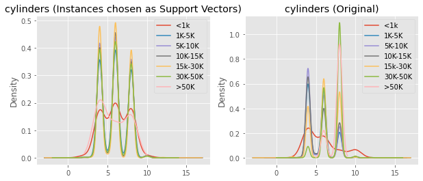

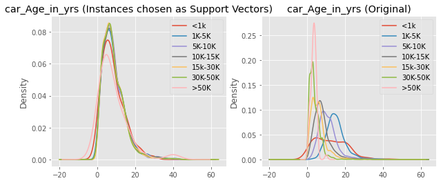

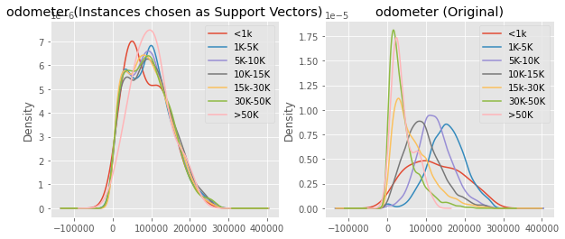

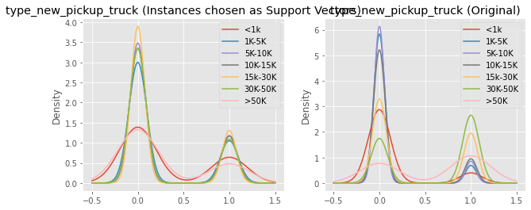

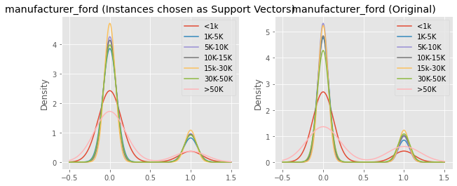

```python
# group the original data and the support vectors
df_grouped_support = df_support.groupby(['price_range_int'])
df_grouped = car_df_ohe_30k.groupby(['price_range_int'])

# plot KDE of continuous variables
vars_to_plot = ['cylinders','car_Age_in_yrs','odometer', 'type_new_pickup_truck','manufacturer_ford']

for v in vars_to_plot:
    plt.figure(figsize=(10,4))
    # plot support vector stats
    plt.subplot(1,2,1)
    ax = df_grouped_support[v].plot.kde()
    plt.legend(['<1k','1K-5K','5K-10K','10K-15K','15k-30K','30K-50K','>50K'])
    plt.title(v+' (Instances chosen as Support Vectors)')

    # plot original distributions
    plt.subplot(1,2,2)
    ax = df_grouped[v].plot.kde()
    plt.legend(['<1k','1K-5K','5K-10K','10K-15K','15k-30K','30K-50K','>50K'])
    plt.title(v+' (Original)')
```